# Jail Data Cleaning

01 October 2018

# Functions

```r
rec_5agree_5num_v1 <- function(var){
  var1 = factor(var,
                levels = c("Strongly Disagree",
                           "Disagree",
                           "Mixed",
                           "Agree",
                           "Strongly Agree"),
                labels = c(1:5))
  var2 = as.numeric(var1)
  return(var2)
}

rec_5agree_5num_v2 <- function(var){
  var1 = factor(var,
                levels = c("Strongly Agree",
                           "Agree",
                           "Mixed",
                           "Disagree",
                           "Strongly Disagree"),
                labels = c(0:4))
  var2 = as.numeric(as.character(var1))
  return(var2)
}

# rec_5agree_3num_v1 <- function(var){
#   var1 = factor(var,
#                 levels = c("Strongly Disagree",
#                            "Disagree",
#                            "Neutral",
#                            "Agree",
#                            "Strongly Agree"),
#                 labels = c(3, 3, 3, 4, 5))
#   var2 = as.numeric(as.character(var1))
#   return(var2)
# }
#
#

rec_5agree_3num_v1 <- function(var){
  var1 = var
  var2 = dplyr::case_when(var1 == "Strongly Disagree" ~ 3,
                          var1 == "Disagree" ~ 3,
                          var1 == "Neutral" ~ 3,
                          var1 == "Agree" ~ 4,
                          var1 == "Strongly Agree" ~ 5)
  var3 = as.numeric(as.character(var2))
  return(var3)
}
```

# Importing Data

```r
Jail_raw <- foreign::read.spss("Data/PICK_Jail_Trimmed.sav",
                               to.data.frame = TRUE )
```

```
re-encoding from UTF-8
```

```r
dplyr::glimpse(Jail_raw)
```

```
Observations: 272
Variables: 101
$ ID                          <dbl> 11500.2, 11501.2, 11502.2, 11549.2...
$ Class                       <dbl> 867, 867, 867, 838, 838, 838, 849,...
$ StartDate                   <dbl> 13654915200, 13654915200, 13654915...
$ EndDate                     <dbl> 13655260800, 13655260800, 13655260...
$ Gender                      <fct> Female, Female, Female, Female, Fe...
$ Hours                       <dbl> 6, 6, 2, 0, 0, 0, 2, 2, 6, 6, 6, 6...
$ Age                         <dbl> 20, 29, 20, 20, 22, 23, 27, 23, NA...
$ Ethnicity                   <fct> Caucasian, Caucasian, Caucasian, C...
$ RelationshipStatusA         <fct> I'm in a romantic relationship, I'...
$ RelationshipStatusB         <fct> Married, Engaged, Married, Single,...
$ RelationshipYears           <dbl> 2, NA, 6, NA, NA, NA, 2, NA, NA, N...
$ RelationshipMonths          <dbl> NA, 7, 2, NA, NA, NA, 7, NA, NA, N...
$ LiveWith                    <fct> My partner or spouse, My partner o...
```

[output cut: 88 more lines]

# Cleaning Data

```r
Jail_clean <- Jail_raw %>%

    dplyr::mutate(DivorcedYou, Div_Dich = if_else(DivorcedYou == 0, "Never Divorced", "Divorced")) %>%

    dplyr::mutate(Div_Dich = factor(Div_Dich)) %>%

    dplyr::mutate(Education_Old = Education) %>%


    dplyr::mutate(Education = dplyr::case_when(Education == "Elementary / middle" ~ "Less than High School Diploma/GED",
                                               Education == "some high school" ~ "Less than High School Diploma/GED",
                                               Education == "High school graduate or GED" ~ "High school graduate or GED",
                                               Education == "Some college" ~ "Some college",
                                               Education == "College or technical degree" ~ "College or technical degree",
                                               Education == "College graduate degree (e.g. MS, PhD)" ~ "Graduate degree")) %>%
    dplyr::mutate(Education = factor(Education,
                                     levels = c("Less than High School Diploma/GED","High school graduate or GED",
                                                "Some college",
                                                "College or technical degree",
                                                "Graduate degree"))) %>%


    dplyr::mutate(Education_collapsed = dplyr::case_when(Education == "Less than High School Diploma/GED" ~ "High school graduate/GED/No degree",
                                               Education == "High school graduate or GED" ~ "High school graduate/GED/No degree",
                                               Education == "Some college" ~ "Some college",
                                               Education == "College or technical degree" ~ "College or technical degree",
                                               Education == "Graduate degree" ~ "Graduate degree")) %>%
    dplyr::mutate(Education_collapsed = factor(Education_collapsed,
                                     levels = c("High school graduate/GED/No degree",
                                                "Some college",
                                                "College or technical degree",
                                                "Graduate degree"))) %>%
    dplyr::mutate(Education_3cat = dplyr::case_when(Education == "Less than High School Diploma/GED" ~ "High school graduate/GED/No degree",
                                               Education == "High school graduate or GED" ~ "High school graduate/GED/No degree",
                                               Education == "Some college" ~ "Some college",
                                               Education == "College or technical degree" ~ "Tech./College/Grad Degree",
                                               Education == "Graduate degree" ~ "Tech./College/Grad Degree")) %>%

    dplyr::mutate(Education_3cat = factor(Education_3cat,
                                          levels = c("High school graduate/GED/No degree",
                                                     "Some college",
                                                     "Tech./College/Grad Degree"))) %>%

    dplyr::mutate(RelEd_Dich = dplyr::case_when(RelationshipEducation == "None" ~ "None",
                                                                   RelationshipEducation == "Some" ~ "Some/A lot",
                                                                   RelationshipEducation == "A lot" ~ "Some/A lot")) %>%
    dplyr::mutate(RelEd_Dich = factor(RelEd_Dich,
                                                         levels = c("None", "Some/A lot"))) %>%


       dplyr::mutate(FinancialWorry_cat = dplyr::case_when(FinancialWorry == "Never" ~ "Never, Hardly Ever",
                                                        FinancialWorry == "Hardly ever" ~ "Never, Hardly Ever",
                                                        FinancialWorry == "Once in a while" ~ "Once in a while",
                                                        FinancialWorry == "Often" ~ "Often, Almost all the time",
                                                        FinancialWorry == "Almost all the time" ~ "Often, Almost all the time")) %>%
    dplyr::mutate(FinancialWorry_cat = factor(FinancialWorry_cat,
                                              levels = c("Never, Hardly Ever",
                                                         "Once in a while",
                                                         "Often, Almost all the time"))) %>%


    dplyr::mutate(Income10K = Income/10000) %>%
    #dplyr::mutate(AgeDecades = Age/10) %>%

# Recoding outcomes at item-level: 5 Text responses to 5 numeric

###Unused Understanding Scale T1

    dplyr::mutate(TimeTogethernessTalk_T1.n =
                      rec_5agree_5num_v1(TimeTogethernessTalk_T1)) %>%
    dplyr::mutate(LoveEmotionalRational_T1.n =
                      rec_5agree_5num_v1(LoveEmotionalRational_T1)) %>%
    dplyr::mutate(IdentifyImportantThings_T1.n =
                      rec_5agree_5num_v1(IdentifyImportantThings_T1)) %>%
    dplyr::mutate(PatternsRepeat_T1.n = rec_5agree_5num_v1(PatternsRepeat_T1)) %>%
    dplyr::mutate(FamilyExperienceImpact_T1.n =
                      rec_5agree_5num_v1(FamilyExperienceImpact_T1)) %>%

###PWB Scale (OQ-5)

    dplyr::mutate(HappyPerson.n = rec_5agree_5num_v2(HappyPerson)) %>%
    dplyr::mutate(SatisfiedLife.n = rec_5agree_5num_v2(SatisfiedLife)) %>%
    dplyr::mutate(SatisfiedRelationship.n = rec_5agree_5num_v2(SatisfiedRelationship)) %>%
    dplyr::mutate(FeelLovedWanted.n = rec_5agree_5num_v2(FeelLovedWanted)) %>%
    dplyr::mutate(RelationshipsFullComplete.n = rec_5agree_5num_v2(RelationshipsFullComplete)) %>%

###WAI Scale

    dplyr::mutate(AppreciatesMe.n = rec_5agree_5num_v1(AppreciatesMe)) %>%
    dplyr::mutate(CaresLikesMe.n = rec_5agree_5num_v1(CaresLikesMe)) %>%
    dplyr::mutate(Trustfacilitator.n = rec_5agree_5num_v1(Trustfacilitator)) %>%
```

```r
###Love is Enough T1

    dplyr::mutate(LoveSufficientMarriage_T1.n =
                      rec_5agree_5num_v1(LoveSufficientMarriage_T1)) %>%
    dplyr::mutate(LoveEnoughSustain_T1.n = rec_5agree_5num_v1(LoveEnoughSustain_T1)) %>%
    dplyr::mutate(FoolWalksAway_T1.n = rec_5agree_5num_v1(FoolWalksAway_T1)) %>%

###Percieved Relationship Skills Pre

    dplyr::mutate(PaceRelationshipSafe.n = rec_5agree_5num_v1(PaceRelationshipSafe)) %>%
    dplyr::mutate(SpotWarningSigns.n = rec_5agree_5num_v1(SpotWarningSigns)) %>%
    dplyr::mutate(WeighProsCons.n = rec_5agree_5num_v1(WeighProsCons)) %>%

###Control Scale T1

    dplyr::mutate(KeepPartnerDoing_T1.n = rec_5agree_5num_v1(KeepPartnerDoing_T1)) %>%
    dplyr::mutate(ForbidPartnerTalking_T1.n = rec_5agree_5num_v1(ForbidPartnerTalking_T1)) %>%
    dplyr::mutate(WouldNotStay_T1.n = rec_5agree_5num_v1(WouldNotStay_T1)) %>%


###Unused Understanding Scale T2

    dplyr::mutate(TimeTogethernessTalk_T2.n =
                      rec_5agree_5num_v1(TimeTogethernessTalk_T2)) %>%
    dplyr::mutate(LoveEmotionalRational_T2.n =
                      rec_5agree_5num_v1(LoveEmotionalRational_T2)) %>%
    dplyr::mutate(IdentifyImportantThings_T2.n =
                      rec_5agree_5num_v1(IdentifyImportantThings_T2)) %>%
    dplyr::mutate(PatternsRepeat_T2.n = rec_5agree_5num_v1(PatternsRepeat_T2)) %>%
    dplyr::mutate(FamilyExperienceImpact_T2.n =
                      rec_5agree_5num_v1(FamilyExperienceImpact_T2)) %>%

###Love is Enough T2

    dplyr::mutate(LoveSufficientMarriage_T2.n =
                      rec_5agree_5num_v1(LoveSufficientMarriage_T2)) %>%
    dplyr::mutate(LoveEnoughSustain_T2.n = rec_5agree_5num_v1(LoveEnoughSustain_T2)) %>%
    dplyr::mutate(FoolWalksAway_T2.n = rec_5agree_5num_v1(FoolWalksAway_T2)) %>%

###Percieved Relationship Skills Before

    dplyr::mutate(PaceRelationshipSafe_Before.n =
                      rec_5agree_5num_v1(PaceRelationshipSafe_Before)) %>%
    dplyr::mutate(SpotWarningSigns_Before.n = rec_5agree_5num_v1(SpotWarningSigns_Before)) %>%
    dplyr::mutate(WeighProsCons_Before.n = rec_5agree_5num_v1(WeighProsCons_Before)) %>%

###Control Scale T2

    dplyr::mutate(KeepPartnerDoing_T2.n = rec_5agree_5num_v1(KeepPartnerDoing_T2)) %>%
    dplyr::mutate(ForbidPartnerTalking_T2.n = rec_5agree_5num_v1(ForbidPartnerTalking_T2)) %>%
    dplyr::mutate(WouldNotStay_T2.n = rec_5agree_5num_v1(WouldNotStay_T2)) %>%


###Percieved Relationship Skills After

    dplyr::mutate(PaceRelationshipSafe_After.n = rec_5agree_5num_v1(PaceRelationshipSafe_After)) %>%
    dplyr::mutate(SpotWarningSigns_After.n = rec_5agree_5num_v1(SpotWarningSigns_After)) %>%
    dplyr::mutate(WeighProsCons_After.n = rec_5agree_5num_v1(WeighProsCons_After)) %>%



# Creating Scales
    ## 5-point Version

###Personal Well Being - OQ-5 Summed
    dplyr::mutate(PWB_Summed2 = dgen::row_sum(HappyPerson.n,
                                                              SatisfiedLife.n,
                                                              SatisfiedRelationship.n,
                                             FeelLovedWanted.n,RelationshipsFullComplete.n,
                                                              maxmiss_n = 0)) %>%
###Working Alliance Inventory - WAI Mean
    dplyr::mutate(WAI = dgen::row_mean(AppreciatesMe.n,
                                                              CaresLikesMe.n,
                                                              Trustfacilitator.n,
                                                              maxmiss_n = 0)) %>%


###Blind Love pre and post
    dplyr::mutate(BL_T1 = dgen::row_mean(LoveSufficientMarriage_T1.n,
                                                      LoveEnoughSustain_T1.n,
                                                      FoolWalksAway_T1.n,
                                                      maxmiss_n = 1)) %>%

    dplyr::mutate(BL_T2 = dgen::row_mean(LoveSufficientMarriage_T2.n,
                                                      LoveEnoughSustain_T2.n,
                                                      FoolWalksAway_T2.n,
                                                      maxmiss_n = 1)) %>%

###Percieved Relationsihp Skills (VF_Scale) pre retro-pre and post
    dplyr::mutate(VF_T1 = dgen::row_mean(PaceRelationshipSafe.n,
                                                            SpotWarningSigns.n,
                                                            WeighProsCons.n,
                                                            maxmiss_n = 1)) %>%

    dplyr::mutate(VF_Before = dgen::row_mean(PaceRelationshipSafe_Before.n,
                                                            SpotWarningSigns_Before.n,
                                                            WeighProsCons_Before.n,
                                                            maxmiss_n = 1)) %>%

    dplyr::mutate(VF_After = dgen::row_mean(PaceRelationshipSafe_After.n,
                                                            SpotWarningSigns_After.n,
                                                            WeighProsCons_After.n,
                                                            maxmiss_n = 1)) %>%
###Control Scale pre and post
    dplyr::mutate(Control_T1 = dgen::row_mean(KeepPartnerDoing_T1.n,
                                                            ForbidPartnerTalking_T1.n,
                                                            WouldNotStay_T1.n,
                                                            maxmiss_n = 1)) %>%

    dplyr::mutate(Control_T2 = dgen::row_mean(KeepPartnerDoing_T2.n,
                                                            ForbidPartnerTalking_T2.n,
                                                            WouldNotStay_T2.n,
                                                            maxmiss_n = 1)) %>%



    dplyr::mutate(BL_Change = BL_T2 - BL_T1) %>%
    dplyr::mutate(VF_Change = VF_After - VF_T1) %>%
    dplyr::mutate(Control_Change = Control_T2 - Control_T1) %>%
```

```r
#Analysis of which variables are missing to determine in analysis sample

    dplyr::mutate(miss.change = dgen::row_nmiss(BL_Change,
                                                VF_Change,
                                                Control_Change)) %>%

    dplyr::mutate(miss.pre = dgen::row_nmiss(BL_T1,
                                               VF_T1,
                                               Control_T1)) %>%

    dplyr::mutate(miss.post = dgen::row_nmiss(BL_T2,
                                               VF_After,
                                               Control_T2)) %>%

    dplyr::mutate(miss.scores = dgen::row_nmiss(BL_T1,
                                               VF_T1,
                                               Control_T1,
                                                BL_T2,
                                               VF_After,
                                               Control_T2)) %>%

    dplyr::mutate(at.least.one.score = ifelse(miss.scores == 6, NA, 1)) %>%

    dplyr::mutate(at.least.one.change.score = ifelse(miss.change == 3, NA, 1)) %>%


     dplyr::mutate(in.analysis.sample1 = complete.cases(
                at.least.one.change.score,
                  Age,
                  Ethnicity,
                  Education,
                  RelEd_Dich,
                  FinancialWorry_cat,
                  Gender,
                  PWB_Summed2,
                  WAI,
                  Div_Dich,
                  Married_Dich
        )) %>%



        dplyr::mutate(in.analysis.sample2 = complete.cases(
                at.least.one.change.score,
                  Age,
                  Ethnicity,
                  Education,
                  RelEd_Dich,
                  FinancialWorry_cat,
                  Gender,
                  PWB_Summed2,
                  WAI,
                  Div_Dich,
                  Married_Dich
        )) %>%



     dplyr::mutate(in.analysis.sample3 = complete.cases(
                at.least.one.change.score,
                  Age,
                  Ethnicity,
                  Education,
                  RelEd_Dich,
                  FinancialWorry_cat,
                  Gender,
                  PWB_Summed2,
                  WAI,
                  #Div_Dich
                  Married_Dich

        )) %>%

            dplyr::mutate(Missing.preds = dgen::row_nmiss(Age,
                  Ethnicity,
                  Education,
                  RelEd_Dich,
                  FinancialWorry_cat,
                  Gender,
                  PWB_Summed2,
                  WAI,
                  Div_Dich,
                  Married_Dich))
rm(Jail_raw)
```

## Sample Sizes

### Missing on predictors

```r
Jail_clean %>%
    furniture::tableF(Missing.preds)
```

```
--------------------------------------------
 Missing.preds Freq CumFreq Percent CumPerc
 0             131  131     48.16%  48.16%
 1             87   218     31.99%  80.15%
 2             32   250     11.76%  91.91%
 3             3    253     1.10%   93.01%
 7             1    254     0.37%   93.38%
 8             14   268     5.15%   98.53%
 9             4    272     1.47%   100.00%
--------------------------------------------
```

```r
Jail_clean %>%
    furniture::tableF(miss.pre)
```

```
---------------------------------------
 miss.pre Freq CumFreq Percent CumPerc
 0        234  234     86.03%  86.03%
 1        7    241     2.57%   88.60%
 2        3    244     1.10%   89.71%
 3        28   272     10.29%  100.00%
---------------------------------------
```

```r
Jail_clean %>%
    furniture::tableF(miss.scores)
```

```
------------------------------------------
 miss.scores Freq CumFreq Percent CumPerc
 0           158  158     58.09%  58.09%
 1           6    164     2.21%   60.29%
 2           2    166     0.74%   61.03%
 3           97   263     35.66%  96.69%
 4           3    266     1.10%   97.79%
 5           1    267     0.37%   98.16%
 6           5    272     1.84%   100.00%
------------------------------------------
```

```r
Jail_clean %>%
    furniture::tableF(miss.change)
```

```
------------------------------------------
 miss.change Freq CumFreq Percent CumPerc
 0           158  158     58.09%  58.09%
 1           6    164     2.21%   60.29%
 2           2    166     0.74%   61.03%
 3           106  272     38.97%  100.00%
------------------------------------------
```

```r
Jail_clean %>%
    furniture::tableF(miss.post)
```

```
----------------------------------------
 miss.post Freq CumFreq Percent CumPerc
 0         187  187     68.75%  68.75%
 1         2    189     0.74%   69.49%
 3         83   272     30.51%  100.00%
----------------------------------------
```

```r
Jail_clean %>%
    furniture::tableF(Age)
```

```
-----------------------------------------------------
 Age     Freq CumFreq Percent CumPerc Valid CumValid
 19      4    4       1.47%   1.47%   1.61% 1.61%
 20      14   18      5.15%   6.62%   5.62% 7.23%
 21      5    23      1.84%   8.46%   2.01% 9.24%
 22      7    30      2.57%   11.03%  2.81% 12.05%
 23      10   40      3.68%   14.71%  4.02% 16.06%
 24      12   52      4.41%   19.12%  4.82% 20.88%
 25      10   62      3.68%   22.79%  4.02% 24.90%
 26      19   81      6.99%   29.78%  7.63% 32.53%
 27      8    89      2.94%   32.72%  3.21% 35.74%
 28      6    95      2.21%   34.93%  2.41% 38.15%
 ...     ...  ...     ...     ...     ...   ...
 49      2    228     0.74%   83.82%  0.80% 91.57%
 50      2    230     0.74%   84.56%  0.80% 92.37%
 51      1    231     0.37%   84.93%  0.40% 92.77%
 52      6    237     2.21%   87.13%  2.41% 95.18%
 53      3    240     1.10%   88.24%  1.20% 96.39%
 54      3    243     1.10%   89.34%  1.20% 97.59%
 57      1    244     0.37%   89.71%  0.40% 97.99%
 58      2    246     0.74%   90.44%  0.80% 98.80%
 61      1    247     0.37%   90.81%  0.40% 99.20%
 62      2    249     0.74%   91.54%  0.80% 100.00%
 Missing 23   272     8.46%   100.00%
-----------------------------------------------------
```

```r
Jail_clean %>%
    furniture::tableF(Ethnicity)
```

```
---------------------------------------------------------------------
 Ethnicity              Freq CumFreq Percent CumPerc Valid  CumValid
 Caucasian              173  173     63.60%  63.60%  69.76% 69.76%
 African-American       4    177     1.47%   65.07%  1.61%  71.37%
 Hispanic/Latino        32   209     11.76%  76.84%  12.90% 84.27%
 Asian/Pacific Islander 3    212     1.10%   77.94%  1.21%  85.48%
 Other                  18   230     6.62%   84.56%  7.26%  92.74%
 Native American        18   248     6.62%   91.18%  7.26%  100.00%
 Missing                24   272     8.82%   100.00%
---------------------------------------------------------------------
```

```r
Jail_clean %>%
    furniture::tableF(Education)
```

```
--------------------------------------------------------------------------------
 Education                         Freq CumFreq Percent CumPerc Valid
 Less than High School Diploma/GED 28   28      10.29%  10.29%  11.48%
 High school graduate or GED       125  153     45.96%  56.25%  51.23%
 Some college                      65   218     23.90%  80.15%  26.64%
 College or technical degree       23   241     8.46%   88.60%  9.43%
 Graduate degree                   3    244     1.10%   89.71%  1.23%
 Missing                           28   272     10.29%  100.00%
 CumValid
 11.48%
 62.70%
 89.34%
 98.77%
 100.00%

--------------------------------------------------------------------------------
```

```r
Jail_clean %>%
    furniture::tableF(Education_Old)
```

```
-------------------------------------------------------------------------------------
 Education_Old                          Freq CumFreq Percent CumPerc
 Elementary / Middle                    0    0       0.00%   0.00%
 some high school                       28   28      10.29%  10.29%
 High school graduate or GED            125  153     45.96%  56.25%
 Some college                           65   218     23.90%  80.15%
 College or technical degree            23   241     8.46%   88.60%
 College graduate degree (e.g. MS, PhD) 3    244     1.10%   89.71%
 Missing                                28   272     10.29%  100.00%
 Valid  CumValid
 0.00%  0.00%
 11.48% 11.48%
 51.23% 62.70%
 26.64% 89.34%
 9.43%  98.77%
 1.23%  100.00%

-------------------------------------------------------------------------------------
```

```r
Jail_clean %>%
    furniture::tableF(RelEd_Dich)
```

```
---------------------------------------------------------
 RelEd_Dich Freq CumFreq Percent CumPerc Valid  CumValid
 None       133  133     48.90%  48.90%  52.78% 52.78%
 Some/A lot 119  252     43.75%  92.65%  47.22% 100.00%
 Missing    20   272     7.35%   100.00%
---------------------------------------------------------
```

```r
Jail_clean %>%
    furniture::tableF(FinancialWorry_cat)
```

```
-------------------------------------------------------------------------
 FinancialWorry_cat         Freq CumFreq Percent CumPerc Valid  CumValid
 Never, Hardly Ever         78   78      28.68%  28.68%  31.45% 31.45%
 Once in a while            73   151     26.84%  55.51%  29.44% 60.89%
 Often, Almost all the time 97   248     35.66%  91.18%  39.11% 100.00%
 Missing                    24   272     8.82%   100.00%
-------------------------------------------------------------------------
```

```r
Jail_clean %>%
    furniture::tableF(Gender)
```

```
------------------------------------------------------
 Gender  Freq CumFreq Percent CumPerc Valid  CumValid
 Male    163  163     59.93%  59.93%  60.15% 60.15%
 Female  108  271     39.71%  99.63%  39.85% 100.00%
 Missing 1    272     0.37%   100.00%
------------------------------------------------------
```

```r
Jail_clean %>%
    furniture::tableF(PWB_Summed)
```

```
---------------------------------------------------------
 PWB_Summed Freq CumFreq Percent CumPerc Valid  CumValid
 0          9    9       3.31%   3.31%   3.73%  3.73%
 1          1    10      0.37%   3.68%   0.41%  4.15%
 2          5    15      1.84%   5.51%   2.07%  6.22%
 3          13   28      4.78%   10.29%  5.39%  11.62%
 4          7    35      2.57%   12.87%  2.90%  14.52%
 5          17   52      6.25%   19.12%  7.05%  21.58%
 6          26   78      9.56%   28.68%  10.79% 32.37%
 7          21   99      7.72%   36.40%  8.71%  41.08%
 8          28   127     10.29%  46.69%  11.62% 52.70%
 9          17   144     6.25%   52.94%  7.05%  59.75%
 ...        ...  ...     ...     ...     ...    ...
 10         27   171     9.93%   62.87%  11.20% 70.95%
 11         17   188     6.25%   69.12%  7.05%  78.01%
 12         14   202     5.15%   74.26%  5.81%  83.82%
 13         11   213     4.04%   78.31%  4.56%  88.38%
 14         7    220     2.57%   80.88%  2.90%  91.29%
 15         6    226     2.21%   83.09%  2.49%  93.78%
 16         8    234     2.94%   86.03%  3.32%  97.10%
 17         1    235     0.37%   86.40%  0.41%  97.51%
 18         5    240     1.84%   88.24%  2.07%  99.59%
 20         1    241     0.37%   88.60%  0.41%  100.00%
 Missing    31   272     11.40%  100.00%
---------------------------------------------------------
```

```r
Jail_clean %>%
    furniture::tableF(PWB_Summed2)
```

```
----------------------------------------------------------
 PWB_Summed2 Freq CumFreq Percent CumPerc Valid  CumValid
 0           9    9       3.31%   3.31%   3.73%  3.73%
 1           1    10      0.37%   3.68%   0.41%  4.15%
 2           5    15      1.84%   5.51%   2.07%  6.22%
 3           13   28      4.78%   10.29%  5.39%  11.62%
 4           7    35      2.57%   12.87%  2.90%  14.52%
 5           17   52      6.25%   19.12%  7.05%  21.58%
 6           26   78      9.56%   28.68%  10.79% 32.37%
 7           21   99      7.72%   36.40%  8.71%  41.08%
 8           28   127     10.29%  46.69%  11.62% 52.70%
 9           17   144     6.25%   52.94%  7.05%  59.75%
 ...         ...  ...     ...     ...     ...    ...
 10          27   171     9.93%   62.87%  11.20% 70.95%
 11          17   188     6.25%   69.12%  7.05%  78.01%
 12          14   202     5.15%   74.26%  5.81%  83.82%
 13          11   213     4.04%   78.31%  4.56%  88.38%
 14          7    220     2.57%   80.88%  2.90%  91.29%
 15          6    226     2.21%   83.09%  2.49%  93.78%
 16          8    234     2.94%   86.03%  3.32%  97.10%
 17          1    235     0.37%   86.40%  0.41%  97.51%
 18          5    240     1.84%   88.24%  2.07%  99.59%
 20          1    241     0.37%   88.60%  0.41%  100.00%
 Missing     31   272     11.40%  100.00%
----------------------------------------------------------
```

```r
Jail_clean %>%
    furniture::tableF(WAI)
```

```
---------------------------------------------------------------
 WAI              Freq CumFreq Percent CumPerc Valid  CumValid
 3                5    5       1.84%   1.84%   2.78%  2.78%
 3.66666666666667 2    7       0.74%   2.57%   1.11%  3.89%
 4                31   38      11.40%  13.97%  17.22% 21.11%
 4.33333333333333 15   53      5.51%   19.49%  8.33%  29.44%
 4.66666666666667 24   77      8.82%   28.31%  13.33% 42.78%
 5                103  180     37.87%  66.18%  57.22% 100.00%
 Missing          92   272     33.82%  100.00%
---------------------------------------------------------------
```

```r
Jail_clean %>%
    furniture::tableF(Div_Dich)
```

```
-------------------------------------------------------------
 Div_Dich       Freq CumFreq Percent CumPerc Valid  CumValid
 Divorced       102  102     37.50%  37.50%  45.13% 45.13%
 Never Divorced 124  226     45.59%  83.09%  54.87% 100.00%
 Missing        46   272     16.91%  100.00%
-------------------------------------------------------------
```

```r
Jail_clean %>%
    furniture::tableF(Married_Dich)
```

```
-----------------------------------------------------------
 Married_Dich Freq CumFreq Percent CumPerc Valid  CumValid
 Married      39   39      14.34%  14.34%  15.85% 15.85%
 Else         207  246     76.10%  90.44%  84.15% 100.00%
 Missing      26   272     9.56%   100.00%
-----------------------------------------------------------
```

```r
Jail_clean %>%
    furniture::tableF(at.least.one.change.score)
```

```
-------------------------------------------------------------------------
 at.least.one.change.score Freq CumFreq Percent CumPerc Valid   CumValid
 1                         166  166     61.03%  61.03%  100.00% 100.00%
 Missing                   106  272     38.97%  100.00%
-------------------------------------------------------------------------
```

### in.analysis.sample1

```r
Jail_clean %>%
    furniture::tableF(in.analysis.sample1)
```

```
--------------------------------------------------
 in.analysis.sample1 Freq CumFreq Percent CumPerc
 FALSE               141  141     51.84%  51.84%
 TRUE                131  272     48.16%  100.00%
--------------------------------------------------
```

### in.analysis.sample2

```r
Jail_clean %>%
    furniture::tableF(in.analysis.sample2)
```

```
--------------------------------------------------
 in.analysis.sample2 Freq CumFreq Percent CumPerc
 FALSE               141  141     51.84%  51.84%
 TRUE                131  272     48.16%  100.00%
--------------------------------------------------
```

### in.analysis.sample3

```r
Jail_clean %>%
    furniture::tableF(in.analysis.sample3)
```

```
--------------------------------------------------
 in.analysis.sample3 Freq CumFreq Percent CumPerc
 FALSE               129  129     47.43%  47.43%
 TRUE                143  272     52.57%  100.00%
--------------------------------------------------
```

## Missing Data for Outcomes?

### Change Scores using in.analysis.sample1 = TRUE

```r
Jail_clean %>% furniture::tableF(miss.change,
                                 splitby = ~in.analysis.sample1)
```

```
Variable:miss.change
```

```
------------------------------------
 FALSE Freq CumFreq Percent CumPerc
 0     32   32      22.70%  22.70%
 1     2    34      1.42%   24.11%
 2     1    35      0.71%   24.82%
 3     106  141     75.18%  100.00%
------------------------------------

-----------------------------------
 TRUE Freq CumFreq Percent CumPerc
 0    126  126     96.18%  96.18%
 1    4    130     3.05%   99.24%
 2    1    131     0.76%   100.00%
-----------------------------------
```

### Scores using in.analysis.sample1 = TRUE

- Unnecessarily restricts to sample having at least one pair of non-missing pre-post data.

```r
Jail_clean %>% furniture::tableF(miss.scores,
                                 splitby = ~in.analysis.sample1)
```

```
Variable:miss.scores
```

```
------------------------------------
 FALSE Freq CumFreq Percent CumPerc
 0     32   32      22.70%  22.70%
 1     2    34      1.42%   24.11%
 2     1    35      0.71%   24.82%
 3     97   132     68.79%  93.62%
 4     3    135     2.13%   95.74%
 5     1    136     0.71%   96.45%
 6     5    141     3.55%   100.00%
------------------------------------

-----------------------------------
 TRUE Freq CumFreq Percent CumPerc
 0    126  126     96.18%  96.18%
 1    4    130     3.05%   99.24%
 2    1    131     0.76%   100.00%
-----------------------------------
```

### Scores using in.analysis.sample3 = TRUE

```r
Jail_clean %>% furniture::tableF(miss.scores,
                                 splitby = ~in.analysis.sample3)
```

```
Variable:miss.scores
```

```
------------------------------------
 FALSE Freq CumFreq Percent CumPerc
 0     21   21      16.28%  16.28%
 1     2    23      1.55%   17.83%
 3     97   120     75.19%  93.02%
 4     3    123     2.33%   95.35%
 5     1    124     0.78%   96.12%
 6     5    129     3.88%   100.00%
------------------------------------

-----------------------------------
 TRUE Freq CumFreq Percent CumPerc
 0    137  137     95.80%  95.80%
 1    4    141     2.80%   98.60%
 2    2    143     1.40%   100.00%
-----------------------------------
```

### Pre Scores using in.analysis.sample3 = TRUE

```r
Jail_clean %>% furniture::tableF(miss.pre,
                                 splitby = ~in.analysis.sample3)
```

```
Variable:miss.pre
```

```
------------------------------------
 FALSE Freq CumFreq Percent CumPerc
 0     97   97      75.19%  75.19%
 1     3    100     2.33%   77.52%
 2     1    101     0.78%   78.29%
 3     28   129     21.71%  100.00%
------------------------------------

-----------------------------------
 TRUE Freq CumFreq Percent CumPerc
 0    137  137     95.80%  95.80%
 1    4    141     2.80%   98.60%
 2    2    143     1.40%   100.00%
-----------------------------------
```

### Post Scores using in.analysis.sample3 = TRUE

```r
Jail_clean %>% furniture::tableF(miss.post,
                                 splitby = ~in.analysis.sample3)
```

```
Variable:miss.post
```

```
------------------------------------
 FALSE Freq CumFreq Percent CumPerc
 0     44   44      34.11%  34.11%
 1     2    46      1.55%   35.66%
 3     83   129     64.34%  100.00%
------------------------------------

-----------------------------------
 TRUE Freq CumFreq Percent CumPerc
 0    143  143     100.00% 100.00%
-----------------------------------
```

## Missing on Predictors

### Using full sample with at least one change score

```r
Jail_clean %>%
    furniture::tableF(Missing.preds,
                      splitby = ~in.analysis.sample1)
```

```
Variable:Missing.preds
```

```
------------------------------------
 FALSE Freq CumFreq Percent CumPerc
 1     87   87      61.70%  61.70%
 2     32   119     22.70%  84.40%
 3     3    122     2.13%   86.52%
 7     1    123     0.71%   87.23%
 8     14   137     9.93%   97.16%
 9     4    141     2.84%   100.00%
------------------------------------

-----------------------------------
 TRUE Freq CumFreq Percent CumPerc
 0    131  131     100.00% 100.00%
-----------------------------------
```

### Using in.analysis.sample

```r
Jail_clean %>%
    furniture::tableF(Missing.preds,
                      splitby = ~in.analysis.sample1)
```

```
Variable:Missing.preds
```

```
------------------------------------
 FALSE Freq CumFreq Percent CumPerc
 1     87   87      61.70%  61.70%
 2     32   119     22.70%  84.40%
 3     3    122     2.13%   86.52%
 7     1    123     0.71%   87.23%
 8     14   137     9.93%   97.16%
 9     4    141     2.84%   100.00%
------------------------------------

-----------------------------------
 TRUE Freq CumFreq Percent CumPerc
 0    131  131     100.00% 100.00%
-----------------------------------
```

### Using in.analysis.sample3

```r
Jail_clean %>%
    furniture::tableF(Missing.preds,
                      splitby = ~in.analysis.sample3)
```

```
Variable:Missing.preds
```

```
------------------------------------
 FALSE Freq CumFreq Percent CumPerc
 1     75   75      58.14%  58.14%
 2     32   107     24.81%  82.95%
 3     3    110     2.33%   85.27%
 7     1    111     0.78%   86.05%
 8     14   125     10.85%  96.90%
 9     4    129     3.10%   100.00%
------------------------------------

-----------------------------------
 TRUE Freq CumFreq Percent CumPerc
 0    131  131     91.61%  91.61%
 1    12   143     8.39%   100.00%
-----------------------------------
```

### Which variables are missing

#### Missing only one: categorical

- We can use Table 1 from the Furniture package to quickly identify who was missing for categorical variables.

```r
Jail_clean %>%
    dplyr::filter(in.analysis.sample3 == FALSE) %>%
    dplyr::filter(Missing.preds == 1) %>%
    dplyr::select(at.least.one.change.score,
                  Age,
                  Ethnicity,
                  Education,
                  RelEd_Dich,
                  FinancialWorry_cat,
                  Gender,
                  Div_Dich,
                  Married_Dich) %>%

    furniture::table1(na.rm = FALSE,
                      digits = 2,
                      #splitby = ~ in.analysis.sample1,
                      test = TRUE) %>% pander::pander()
```

```
--------------------------------------------------------
                                      Mean/Count (SD/%)
                                      n = 75
 at.least.one.change.score
                                      1.00 (0.00)
 Age
                                      31.55 (9.39)
 Ethnicity
    Caucasian                         51 (68%)
    African-American                  3 (4%)
    Hispanic/Latino                   9 (12%)
    Asian/Pacific Islander            1 (1.3%)
    Other                             3 (4%)
    Native American                   6 (8%)
    NA                                2 (2.7%)
 Education
    Less than High School Diploma/GED 9 (12%)
    High school graduate or GED       41 (54.7%)
    Some college                      16 (21.3%)
    College or technical degree       7 (9.3%)
    Graduate degree                   1 (1.3%)
    NA                                1 (1.3%)
 RelEd_Dich
    None                              42 (56%)
    Some/A lot                        33 (44%)
    NA                                0 (0%)
 FinancialWorry_cat
    Never, Hardly Ever                25 (33.3%)
    Once in a while                   24 (32%)
    Often, Almost all the time        26 (34.7%)
    NA                                0 (0%)
 Gender
    Male                              40 (53.3%)
    Female                            35 (46.7%)
    NA                                0 (0%)
 Div_Dich
    Divorced                          34 (45.3%)
    Never Divorced                    41 (54.7%)
    NA                                0 (0%)
 Married_Dich
    Married                           13 (17.3%)
    Else                              58 (77.3%)
    NA                                4 (5.3%)
--------------------------------------------------------
```

Table continues below

| at.least.one.change.score | Age | Ethnicity |
| --- | --- | --- |
| NA | 20 | Caucasian |
| NA | 20 | Caucasian |
| NA | 22 | Caucasian |
| NA | 27 | Caucasian |
| NA | 23 | Hispanic/Latino |
| 1 | NA | Caucasian |
| 1 | 30 | Native American |
| 1 | NA | Caucasian |
| NA | 30 | Hispanic/Latino |
| 1 | 50 | Caucasian |
| NA | 45 | African-American |
| 1 | 23 | Caucasian |
| NA | 35 | Other |
| NA | 24 | Hispanic/Latino |
| 1 | 36 | NA |
| NA | 58 | Caucasian |
| 1 | 30 | NA |
| 1 | 23 | Caucasian |
| NA | 41 | Caucasian |
| NA | 32 | Caucasian |
| NA | 19 | Caucasian |
| 1 | 25 | Caucasian |
| NA | 36 | Hispanic/Latino |
| NA | 20 | Hispanic/Latino |
| NA | 24 | Caucasian |
| NA | 31 | Other |
| 1 | 39 | Caucasian |
| NA | 30 | Caucasian |
| NA | 27 | Other |
| NA | 30 | Caucasian |
| NA | 54 | Caucasian |
| NA | 35 | Hispanic/Latino |
| NA | 33 | Caucasian |
| 1 | 29 | Hispanic/Latino |
| NA | 36 | Caucasian |
| NA | 20 | African-American |
| NA | 26 | African-American |
| NA | 23 | Caucasian |
| NA | 19 | Caucasian |
| NA | 22 | Caucasian |
| NA | 33 | Caucasian |
| NA | 36 | Caucasian |
| NA | 46 | Caucasian |
| NA | 37 | Caucasian |
| NA | 29 | Caucasian |
| NA | 24 | Caucasian |
| NA | 41 | Caucasian |
| NA | 45 | Caucasian |
| NA | 31 | Caucasian |
| NA | 29 | Native American |
| NA | 31 | Caucasian |
| NA | 22 | Caucasian |
| NA | 20 | Caucasian |
| NA | 26 | Native American |
| NA | 35 | Caucasian |
| NA | 52 | Caucasian |
| NA | 26 | Asian/Pacific Islander |
| NA | 21 | Caucasian |
| NA | 26 | Native American |
| 1 | 52 | Native American |
| NA | 21 | Hispanic/Latino |
| NA | 28 | Caucasian |
| NA | 39 | Caucasian |
| NA | 37 | Caucasian |
| NA | 26 | Caucasian |
| NA | 31 | Hispanic/Latino |
| NA | 23 | Native American |
| NA | 29 | Caucasian |
| NA | 48 | Caucasian |
| NA | 29 | Caucasian |
| 1 | 27 | Caucasian |
| NA | 36 | Caucasian |
| NA | 34 | Caucasian |
| 1 | 39 | Caucasian |
| 1 | 47 | Caucasian |

Table continues below

| Education | RelEd_Dich | FinancialWorry_cat | Gender |
| --- | --- | --- | --- |
| High school graduate or GED | Some/A lot | Once in a while | Female |
| High school graduate or GED | None | Once in a while | Female |
| Some college | None | Never, Hardly Ever | Female |
| Less than High School Diploma/GED | Some/A lot | Never, Hardly Ever | Female |
| High school graduate or GED | None | Never, Hardly Ever | Female |
| College or technical degree | None | Often, Almost all the time | Male |
| NA | Some/A lot | Never, Hardly Ever | Male |
| High school graduate or GED | None | Never, Hardly Ever | Male |
| High school graduate or GED | None | Once in a while | Male |
| High school graduate or GED | Some/A lot | Never, Hardly Ever | Male |
| High school graduate or GED | Some/A lot | Never, Hardly Ever | Male |
| High school graduate or GED | None | Often, Almost all the time | Male |
| High school graduate or GED | Some/A lot | Often, Almost all the time | Male |
| High school graduate or GED | Some/A lot | Never, Hardly Ever | Male |
| High school graduate or GED | None | Often, Almost all the time | Female |
| High school graduate or GED | None | Often, Almost all the time | Female |
| Some college | None | Often, Almost all the time | Female |
| High school graduate or GED | None | Once in a while | Male |
| Graduate degree | Some/A lot | Never, Hardly Ever | Male |
| Less than High School Diploma/GED | Some/A lot | Once in a while | Female |
| High school graduate or GED | None | Once in a while | Male |
| High school graduate or GED | Some/A lot | Never, Hardly Ever | Male |
| Less than High School Diploma/GED | Some/A lot | Never, Hardly Ever | Male |
| Less than High School Diploma/GED | Some/A lot | Once in a while | Female |
| Some college | None | Often, Almost all the time | Female |
| Less than High School Diploma/GED | None | Often, Almost all the time | Female |
| High school graduate or GED | Some/A lot | Once in a while | Male |
| High school graduate or GED | None | Often, Almost all the time | Male |
| Less than High School Diploma/GED | None | Never, Hardly Ever | Male |
| High school graduate or GED | None | Never, Hardly Ever | Male |
| High school graduate or GED | Some/A lot | Never, Hardly Ever | Male |
| High school graduate or GED | Some/A lot | Often, Almost all the time | Male |
| High school graduate or GED | None | Often, Almost all the time | Female |
| High school graduate or GED | None | Once in a while | Male |
| High school graduate or GED | Some/A lot | Often, Almost all the time | Male |
| Less than High School Diploma/GED | None | Never, Hardly Ever | Male |
| High school graduate or GED | None | Never, Hardly Ever | Male |
| High school graduate or GED | Some/A lot | Never, Hardly Ever | Female |
| Some college | Some/A lot | Once in a while | Female |
| Some college | None | Once in a while | Female |
| High school graduate or GED | Some/A lot | Never, Hardly Ever | Female |
| High school graduate or GED | None | Often, Almost all the time | Female |
| Some college | None | Once in a while | Female |
| Some college | Some/A lot | Often, Almost all the time | Female |
| Less than High School Diploma/GED | Some/A lot | Often, Almost all the time | Female |
| Less than High School Diploma/GED | None | Often, Almost all the time | Female |
| High school graduate or GED | Some/A lot | Never, Hardly Ever | Male |
| High school graduate or GED | Some/A lot | Once in a while | Male |
| Some college | None | Never, Hardly Ever | Male |
| High school graduate or GED | None | Never, Hardly Ever | Male |
| College or technical degree | None | Once in a while | Female |
| Some college | Some/A lot | Never, Hardly Ever | Female |
| High school graduate or GED | None | Often, Almost all the time | Female |
| Some college | Some/A lot | Often, Almost all the time | Female |
| College or technical degree | None | Never, Hardly Ever | Male |
| High school graduate or GED | None | Once in a while | Male |
| College or technical degree | Some/A lot | Often, Almost all the time | Male |
| Some college | Some/A lot | Often, Almost all the time | Female |
| High school graduate or GED | None | Never, Hardly Ever | Female |
| College or technical degree | None | Once in a while | Female |
| High school graduate or GED | Some/A lot | Once in a while | Female |
| Some college | None | Once in a while | Female |
| High school graduate or GED | None | Never, Hardly Ever | Male |
| College or technical degree | Some/A lot | Once in a while | Male |
| Some college | None | Once in a while | Male |
| High school graduate or GED | Some/A lot | Once in a while | Male |
| High school graduate or GED | None | Often, Almost all the time | Female |
| High school graduate or GED | None | Often, Almost all the time | Male |
| Some college | Some/A lot | Once in a while | Male |
| High school graduate or GED | None | Once in a while | Female |
| College or technical degree | None | Once in a while | Male |
| High school graduate or GED | Some/A lot | Often, Almost all the time | Male |
| High school graduate or GED | None | Often, Almost all the time | Male |
| Some college | None | Often, Almost all the time | Female |
| Some college | Some/A lot | Often, Almost all the time | Female |

| Div_Dich | Married_Dich |
| --- | --- |
| Never Divorced | Married |
| Never Divorced | Else |
| Divorced | Else |
| Never Divorced | Else |
| Never Divorced | Else |
| Divorced | Else |
| Divorced | Else |
| Divorced | Else |
| Never Divorced | Else |
| Divorced | Married |
| Never Divorced | Else |
| Never Divorced | Else |
| Never Divorced | Else |
| Never Divorced | Else |
| Divorced | Else |
| Divorced | Else |
| Never Divorced | Married |
| Never Divorced | Else |
| Divorced | Else |
| Divorced | Else |
| Never Divorced | Else |
| Divorced | Else |
| Divorced | Else |
| Never Divorced | Else |
| Never Divorced | Else |
| Never Divorced | Married |
| Divorced | NA |
| Divorced | Else |
| Divorced | Married |
| Never Divorced | Else |
| Divorced | Else |
| Never Divorced | Else |
| Never Divorced | Else |
| Never Divorced | NA |
| Never Divorced | Else |
| Never Divorced | Else |
| Never Divorced | Married |
| Never Divorced | Married |
| Never Divorced | Else |
| Divorced | Else |
| Never Divorced | Else |
| Divorced | Married |
| Never Divorced | Else |
| Divorced | Else |
| Divorced | Else |
| Divorced | Else |
| Divorced | Married |
| Divorced | Else |
| Never Divorced | Else |
| Divorced | Else |
| Divorced | Else |
| Divorced | Else |
| Never Divorced | Else |
| Divorced | Married |
| Never Divorced | Else |
| Divorced | Else |
| Never Divorced | Married |
| Never Divorced | Else |
| Never Divorced | Else |
| Never Divorced | Else |
| Never Divorced | Else |
| Divorced | Married |
| Divorced | Married |
| Divorced | Else |
| Never Divorced | Else |
| Never Divorced | Else |
| Never Divorced | Else |
| Never Divorced | Else |
| Divorced | Else |
| Never Divorced | Else |
| Divorced | Else |
| Never Divorced | Else |
| Never Divorced | Else |
| Divorced | NA |
| Divorced | NA |

#### Missing only one: continuous

```r
#Jail_clean %>%
    #dplyr::filter(in.analysis.sample1 == FALSE) %>%
    #dplyr::filter(Missing.preds == 1) %>%
    #furniture::tableF(AgeDecades)
```

# Checking Coding Accuracy

## Age

```r
#Jail_clean %>%
    #furniture::tableF(AgeDecades)

Jail_clean %>%
    furniture::tableF(Age)
```

```
-----------------------------------------------------
 Age     Freq CumFreq Percent CumPerc Valid CumValid
 19      4    4       1.47%   1.47%   1.61% 1.61%
 20      14   18      5.15%   6.62%   5.62% 7.23%
 21      5    23      1.84%   8.46%   2.01% 9.24%
 22      7    30      2.57%   11.03%  2.81% 12.05%
 23      10   40      3.68%   14.71%  4.02% 16.06%
 24      12   52      4.41%   19.12%  4.82% 20.88%
 25      10   62      3.68%   22.79%  4.02% 24.90%
 26      19   81      6.99%   29.78%  7.63% 32.53%
 27      8    89      2.94%   32.72%  3.21% 35.74%
 28      6    95      2.21%   34.93%  2.41% 38.15%
 ...     ...  ...     ...     ...     ...   ...
 49      2    228     0.74%   83.82%  0.80% 91.57%
 50      2    230     0.74%   84.56%  0.80% 92.37%
 51      1    231     0.37%   84.93%  0.40% 92.77%
 52      6    237     2.21%   87.13%  2.41% 95.18%
 53      3    240     1.10%   88.24%  1.20% 96.39%
 54      3    243     1.10%   89.34%  1.20% 97.59%
 57      1    244     0.37%   89.71%  0.40% 97.99%
 58      2    246     0.74%   90.44%  0.80% 98.80%
 61      1    247     0.37%   90.81%  0.40% 99.20%
 62      2    249     0.74%   91.54%  0.80% 100.00%
 Missing 23   272     8.46%   100.00%
-----------------------------------------------------
```

```r
Jail_clean %>%
    furniture::tableF(Age_Groups)
```

```
---------------------------------------------------------
 Age_Groups Freq CumFreq Percent CumPerc Valid  CumValid
 18-30      115  115     42.28%  42.28%  46.18% 46.18%
 31-40      81   196     29.78%  72.06%  32.53% 78.71%
 41-50      34   230     12.50%  84.56%  13.65% 92.37%
 51+        19   249     6.99%   91.54%  7.63%  100.00%
 Missing    23   272     8.46%   100.00%
---------------------------------------------------------
```

## Ethnicity

```r
Jail_clean %>%
    furniture::tableF(Ethnicity)
```

```
---------------------------------------------------------------------
 Ethnicity              Freq CumFreq Percent CumPerc Valid  CumValid
 Caucasian              173  173     63.60%  63.60%  69.76% 69.76%
 African-American       4    177     1.47%   65.07%  1.61%  71.37%
 Hispanic/Latino        32   209     11.76%  76.84%  12.90% 84.27%
 Asian/Pacific Islander 3    212     1.10%   77.94%  1.21%  85.48%
 Other                  18   230     6.62%   84.56%  7.26%  92.74%
 Native American        18   248     6.62%   91.18%  7.26%  100.00%
 Missing                24   272     8.82%   100.00%
---------------------------------------------------------------------
```

```r
Jail_clean %>%
    furniture::tableF(Ethnicity_Dich)
```

```
-------------------------------------------------------------
 Ethnicity_Dich Freq CumFreq Percent CumPerc Valid  CumValid
 Caucasian      173  173     63.60%  63.60%  69.76% 69.76%
 Else           75   248     27.57%  91.18%  30.24% 100.00%
 Missing        24   272     8.82%   100.00%
-------------------------------------------------------------
```

## Education

```r
Jail_clean %>%
    furniture::tableF(Education_Old)
```

```
-------------------------------------------------------------------------------------
 Education_Old                          Freq CumFreq Percent CumPerc
 Elementary / Middle                    0    0       0.00%   0.00%
 some high school                       28   28      10.29%  10.29%
 High school graduate or GED            125  153     45.96%  56.25%
 Some college                           65   218     23.90%  80.15%
 College or technical degree            23   241     8.46%   88.60%
 College graduate degree (e.g. MS, PhD) 3    244     1.10%   89.71%
 Missing                                28   272     10.29%  100.00%
 Valid  CumValid
 0.00%  0.00%
 11.48% 11.48%
 51.23% 62.70%
 26.64% 89.34%
 9.43%  98.77%
 1.23%  100.00%

-------------------------------------------------------------------------------------
```

```r
Jail_clean %>%
    furniture::tableF(Education)
```

```
--------------------------------------------------------------------------------
 Education                         Freq CumFreq Percent CumPerc Valid
 Less than High School Diploma/GED 28   28      10.29%  10.29%  11.48%
 High school graduate or GED       125  153     45.96%  56.25%  51.23%
 Some college                      65   218     23.90%  80.15%  26.64%
 College or technical degree       23   241     8.46%   88.60%  9.43%
 Graduate degree                   3    244     1.10%   89.71%  1.23%
 Missing                           28   272     10.29%  100.00%
 CumValid
 11.48%
 62.70%
 89.34%
 98.77%
 100.00%

--------------------------------------------------------------------------------
```

```r
Jail_clean %>%
    furniture::tableF(Education_collapsed)
```

```
---------------------------------------------------------------------------------
 Education_collapsed                Freq CumFreq Percent CumPerc Valid
 High school graduate/GED/No degree 153  153     56.25%  56.25%  62.70%
 Some college                       65   218     23.90%  80.15%  26.64%
 College or technical degree        23   241     8.46%   88.60%  9.43%
 Graduate degree                    3    244     1.10%   89.71%  1.23%
 Missing                            28   272     10.29%  100.00%
 CumValid
 62.70%
 89.34%
 98.77%
 100.00%

---------------------------------------------------------------------------------
```

```r
Jail_clean %>%
    furniture::tableF(Education_3cat)
```

```
---------------------------------------------------------------------------------
 Education_3cat                     Freq CumFreq Percent CumPerc Valid
 High school graduate/GED/No degree 153  153     56.25%  56.25%  62.70%
 Some college                       65   218     23.90%  80.15%  26.64%
 Tech./College/Grad Degree          26   244     9.56%   89.71%  10.66%
 Missing                            28   272     10.29%  100.00%
 CumValid
 62.70%
 89.34%
 100.00%

---------------------------------------------------------------------------------
```

## Income

```r
Jail_clean %>%
    furniture::tableF(Income)
```

```
-----------------------------------------------------
 Income  Freq CumFreq Percent CumPerc Valid CumValid
 0       8    8       2.94%   2.94%   3.77% 3.77%
 1000    2    10      0.74%   3.68%   0.94% 4.72%
 2000    4    14      1.47%   5.15%   1.89% 6.60%
 2500    1    15      0.37%   5.51%   0.47% 7.08%
 4000    2    17      0.74%   6.25%   0.94% 8.02%
 5000    13   30      4.78%   11.03%  6.13% 14.15%
 7000    2    32      0.74%   11.76%  0.94% 15.09%
 7500    2    34      0.74%   12.50%  0.94% 16.04%
 9000    1    35      0.37%   12.87%  0.47% 16.51%
 10000   11   46      4.04%   16.91%  5.19% 21.70%
 ...     ...  ...     ...     ...     ...   ...
 70000   1    188     0.37%   69.12%  0.47% 88.68%
 73000   1    189     0.37%   69.49%  0.47% 89.15%
 73500   1    190     0.37%   69.85%  0.47% 89.62%
 75000   2    192     0.74%   70.59%  0.94% 90.57%
 80000   1    193     0.37%   70.96%  0.47% 91.04%
 82500   1    194     0.37%   71.32%  0.47% 91.51%
 85000   4    198     1.47%   72.79%  1.89% 93.40%
 90000   1    199     0.37%   73.16%  0.47% 93.87%
 95000   2    201     0.74%   73.90%  0.94% 94.81%
 1e+05   11   212     4.04%   77.94%  5.19% 100.00%
 Missing 60   272     22.06%  100.00%
-----------------------------------------------------
```

```r
Jail_clean %>%
    furniture::tableF(Income10K)
```

```
-------------------------------------------------------
 Income10K Freq CumFreq Percent CumPerc Valid CumValid
 0         8    8       2.94%   2.94%   3.77% 3.77%
 0.1       2    10      0.74%   3.68%   0.94% 4.72%
 0.2       4    14      1.47%   5.15%   1.89% 6.60%
 0.25      1    15      0.37%   5.51%   0.47% 7.08%
 0.4       2    17      0.74%   6.25%   0.94% 8.02%
 0.5       13   30      4.78%   11.03%  6.13% 14.15%
 0.7       2    32      0.74%   11.76%  0.94% 15.09%
 0.75      2    34      0.74%   12.50%  0.94% 16.04%
 0.9       1    35      0.37%   12.87%  0.47% 16.51%
 1         11   46      4.04%   16.91%  5.19% 21.70%
 ...       ...  ...     ...     ...     ...   ...
 7         1    188     0.37%   69.12%  0.47% 88.68%
 7.3       1    189     0.37%   69.49%  0.47% 89.15%
 7.35      1    190     0.37%   69.85%  0.47% 89.62%
 7.5       2    192     0.74%   70.59%  0.94% 90.57%
 8         1    193     0.37%   70.96%  0.47% 91.04%
 8.25      1    194     0.37%   71.32%  0.47% 91.51%
 8.5       4    198     1.47%   72.79%  1.89% 93.40%
 9         1    199     0.37%   73.16%  0.47% 93.87%
 9.5       2    201     0.74%   73.90%  0.94% 94.81%
 10        11   212     4.04%   77.94%  5.19% 100.00%
 Missing   60   272     22.06%  100.00%
-------------------------------------------------------
```

## Gender

```r
Jail_clean %>%
    furniture::tableF(Gender)
```

```
------------------------------------------------------
 Gender  Freq CumFreq Percent CumPerc Valid  CumValid
 Male    163  163     59.93%  59.93%  60.15% 60.15%
 Female  108  271     39.71%  99.63%  39.85% 100.00%
 Missing 1    272     0.37%   100.00%
------------------------------------------------------
```

## Divorce History

```r
Jail_clean %>%
    furniture::tableF(Div_Dich)
```

```
-------------------------------------------------------------
 Div_Dich       Freq CumFreq Percent CumPerc Valid  CumValid
 Divorced       102  102     37.50%  37.50%  45.13% 45.13%
 Never Divorced 124  226     45.59%  83.09%  54.87% 100.00%
 Missing        46   272     16.91%  100.00%
-------------------------------------------------------------
```

## Working Alliance Inventory

```r
Jail_clean %>%
    furniture::tableF(WAI)
```

```
---------------------------------------------------------------
 WAI              Freq CumFreq Percent CumPerc Valid  CumValid
 3                5    5       1.84%   1.84%   2.78%  2.78%
 3.66666666666667 2    7       0.74%   2.57%   1.11%  3.89%
 4                31   38      11.40%  13.97%  17.22% 21.11%
 4.33333333333333 15   53      5.51%   19.49%  8.33%  29.44%
 4.66666666666667 24   77      8.82%   28.31%  13.33% 42.78%
 5                103  180     37.87%  66.18%  57.22% 100.00%
 Missing          92   272     33.82%  100.00%
---------------------------------------------------------------
```

## Financial Strain

```r
Jail_clean %>%
    furniture::tableF(FinancialWorry)
```

```
------------------------------------------------------------------
 FinancialWorry      Freq CumFreq Percent CumPerc Valid  CumValid
 Never               19   19      6.99%   6.99%   7.66%  7.66%
 Hardly ever         59   78      21.69%  28.68%  23.79% 31.45%
 Once in a while     73   151     26.84%  55.51%  29.44% 60.89%
 Often               66   217     24.26%  79.78%  26.61% 87.50%
 Almost all the time 31   248     11.40%  91.18%  12.50% 100.00%
 Missing             24   272     8.82%   100.00%
------------------------------------------------------------------
```

```r
Jail_clean %>%
    furniture::tableF(FinancialWorry_cat)
```

```
-------------------------------------------------------------------------
 FinancialWorry_cat         Freq CumFreq Percent CumPerc Valid  CumValid
 Never, Hardly Ever         78   78      28.68%  28.68%  31.45% 31.45%
 Once in a while            73   151     26.84%  55.51%  29.44% 60.89%
 Often, Almost all the time 97   248     35.66%  91.18%  39.11% 100.00%
 Missing                    24   272     8.82%   100.00%
-------------------------------------------------------------------------
```

## Prior Relationship Education

```r
Jail_clean %>%
    furniture::tableF(RelationshipEducation)
```

```
--------------------------------------------------------------------
 RelationshipEducation Freq CumFreq Percent CumPerc Valid  CumValid
 None                  133  133     48.90%  48.90%  52.78% 52.78%
 Some                  108  241     39.71%  88.60%  42.86% 95.63%
 A lot                 11   252     4.04%   92.65%  4.37%  100.00%
 Missing               20   272     7.35%   100.00%
--------------------------------------------------------------------
```

```r
Jail_clean %>%
    furniture::tableF(RelEd_Dich)
```

```
---------------------------------------------------------
 RelEd_Dich Freq CumFreq Percent CumPerc Valid  CumValid
 None       133  133     48.90%  48.90%  52.78% 52.78%
 Some/A lot 119  252     43.75%  92.65%  47.22% 100.00%
 Missing    20   272     7.35%   100.00%
---------------------------------------------------------
```

# Reviewing Frequencies and Distributions, and Selecting Predictor Variable Versions

## Age

- Age

```r
Jail_clean %>%
    dplyr::filter(in.analysis.sample1 == TRUE) %>%
    furniture::tableF(Age, n = 40)
```

```
----------------------------------
 Age Freq CumFreq Percent CumPerc
 19  1    1       0.76%   0.76%
 20  4    5       3.05%   3.82%
 21  3    8       2.29%   6.11%
 22  4    12      3.05%   9.16%
 23  4    16      3.05%   12.21%
 24  8    24      6.11%   18.32%
 25  8    32      6.11%   24.43%
 26  7    39      5.34%   29.77%
 27  3    42      2.29%   32.06%
 28  5    47      3.82%   35.88%
 29  4    51      3.05%   38.93%
 30  6    57      4.58%   43.51%
 31  6    63      4.58%   48.09%
```

[output cut: 24 more lines]

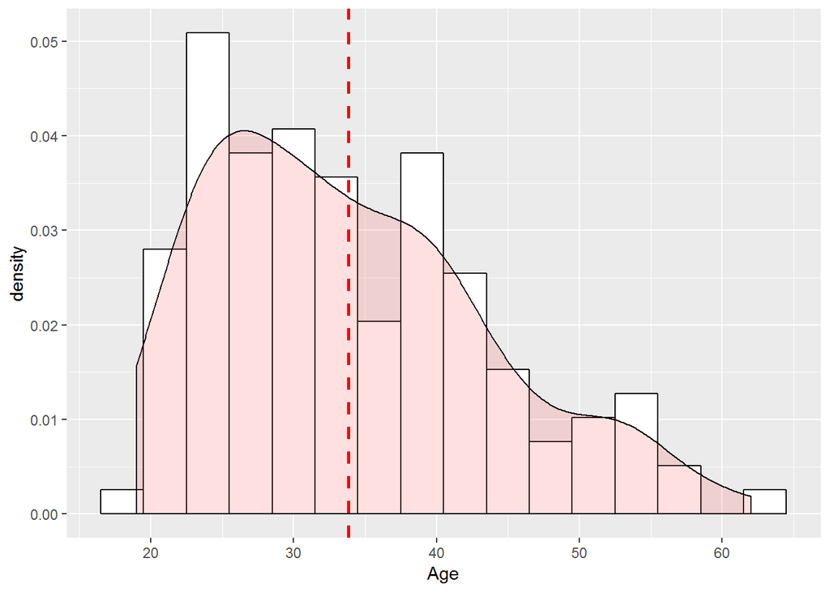

```r
Jail_clean %>%
    dplyr::filter(in.analysis.sample1 == TRUE) %>%
    ggplot2::ggplot(aes(x = Age)) +
    geom_histogram(aes(y=..density..),
                   binwidth=3,
                   colour="black",
                   fill="white") +
    geom_density(alpha=.2,
                 fill="#FF6666") +
    geom_vline(aes(xintercept=mean(Age, na.rm=T)),   # Ignore NA values for mean
               color="red",
               linetype="dashed",
               size=1)
```

- Age in Decades

```r
#Jail_clean %>%
    #dplyr::filter(in.analysis.sample1 == TRUE) %>%
    #furniture::tableF(AgeDecades)
```

```r
Jail_clean %>%
    dplyr::filter(in.analysis.sample1 == TRUE) %>%
    furniture::tableF(Age_Groups)
```

```
-----------------------------------------
 Age_Groups Freq CumFreq Percent CumPerc
 18-30      57   57      43.51%  43.51%
 31-40      43   100     32.82%  76.34%
 41-50      20   120     15.27%  91.60%
 51+        11   131     8.40%   100.00%
-----------------------------------------
```

## Ethnicity

- All Categories

```r
Jail_clean %>%
    dplyr::filter(in.analysis.sample1 == TRUE) %>%
    furniture::tableF(Ethnicity)
```

```
-----------------------------------------------------
 Ethnicity              Freq CumFreq Percent CumPerc
 Caucasian              96   96      73.28%  73.28%
 African-American       0    96      0.00%   73.28%
 Hispanic/Latino        14   110     10.69%  83.97%
 Asian/Pacific Islander 2    112     1.53%   85.50%
 Other                  8    120     6.11%   91.60%
 Native American        11   131     8.40%   100.00%
-----------------------------------------------------
```

- Collapsing categories to two

```r
Jail_clean %>%
    dplyr::filter(in.analysis.sample1 == TRUE) %>%
    furniture::tableF(Ethnicity_Dich)
```

```
---------------------------------------------
 Ethnicity_Dich Freq CumFreq Percent CumPerc
 Caucasian      96   96      73.28%  73.28%
 Else           35   131     26.72%  100.00%
---------------------------------------------
```

## Education

- Collapsing Elementary and some High School

```r
Jail_clean %>%
    dplyr::filter(in.analysis.sample1 == TRUE) %>%
    furniture::tableF(Education)
```

```
----------------------------------------------------------------
 Education                         Freq CumFreq Percent CumPerc
 Less than High School Diploma/GED 13   13      9.92%   9.92%
 High school graduate or GED       65   78      49.62%  59.54%
 Some college                      37   115     28.24%  87.79%
 College or technical degree       14   129     10.69%  98.47%
 Graduate degree                   2    131     1.53%   100.00%
----------------------------------------------------------------
```

- Collapsing Less than High School and High School/GED

```r
Jail_clean %>%
    dplyr::filter(in.analysis.sample1 == TRUE) %>%
    furniture::tableF(Education_collapsed)
```

```
-----------------------------------------------------------------
 Education_collapsed                Freq CumFreq Percent CumPerc
 High school graduate/GED/No degree 78   78      59.54%  59.54%
 Some college                       37   115     28.24%  87.79%
 College or technical degree        14   129     10.69%  98.47%
 Graduate degree                    2    131     1.53%   100.00%
-----------------------------------------------------------------
```

- Collapsing Graduate Degree and College/Technical Degree

```r
Jail_clean %>%
    dplyr::filter(in.analysis.sample1 == TRUE) %>%
    furniture::tableF(Education_3cat)
```

```
-----------------------------------------------------------------
 Education_3cat                     Freq CumFreq Percent CumPerc
 High school graduate/GED/No degree 78   78      59.54%  59.54%
 Some college                       37   115     28.24%  87.79%
 Tech./College/Grad Degree          16   131     12.21%  100.00%
-----------------------------------------------------------------
```

## Income

```r
Jail_clean %>%
    dplyr::filter(in.analysis.sample1 == TRUE) %>%
    furniture::tableF(Income)
```

```
-----------------------------------------------------
 Income  Freq CumFreq Percent CumPerc Valid CumValid
 0       4    4       3.05%   3.05%   3.54% 3.54%
 1000    1    5       0.76%   3.82%   0.88% 4.42%
 2000    1    6       0.76%   4.58%   0.88% 5.31%
 4000    2    8       1.53%   6.11%   1.77% 7.08%
 5000    8    16      6.11%   12.21%  7.08% 14.16%
 7500    2    18      1.53%   13.74%  1.77% 15.93%
 10000   5    23      3.82%   17.56%  4.42% 20.35%
 13000   2    25      1.53%   19.08%  1.77% 22.12%
 13500   1    26      0.76%   19.85%  0.88% 23.01%
 15000   5    31      3.82%   23.66%  4.42% 27.43%
 ...     ...  ...     ...     ...     ...   ...
 55000   4    94      3.05%   71.76%  3.54% 83.19%
 59000   1    95      0.76%   72.52%  0.88% 84.07%
 60000   4    99      3.05%   75.57%  3.54% 87.61%
 61000   1    100     0.76%   76.34%  0.88% 88.50%
 70000   1    101     0.76%   77.10%  0.88% 89.38%
 73500   1    102     0.76%   77.86%  0.88% 90.27%
 75000   1    103     0.76%   78.63%  0.88% 91.15%
 85000   3    106     2.29%   80.92%  2.65% 93.81%
 95000   2    108     1.53%   82.44%  1.77% 95.58%
 1e+05   5    113     3.82%   86.26%  4.42% 100.00%
 Missing 18   131     13.74%  100.00%
-----------------------------------------------------
```

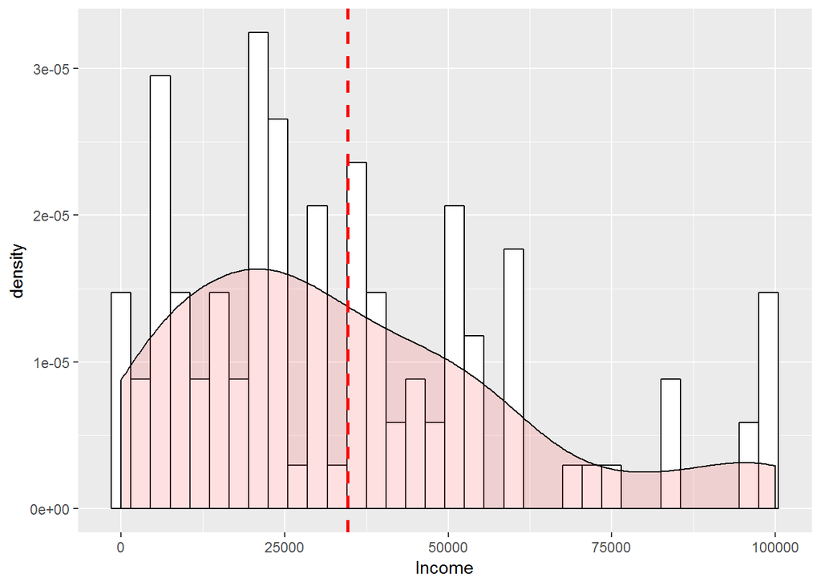

```r
Jail_clean %>%
    dplyr::filter(in.analysis.sample1 == TRUE) %>%
    ggplot2::ggplot(aes(x = Income)) +
    geom_histogram(aes(y=..density..),
                   binwidth=3000,
                   colour="black",
                   fill="white") +
    geom_density(alpha=.2,
                 fill="#FF6666") +
    geom_vline(aes(xintercept=mean(Income, na.rm=T)),   # Ignore NA values for mean
               color="red",
               linetype="dashed",
               size=1)
```

```r
Jail_clean %>%
    dplyr::filter(in.analysis.sample1 == TRUE) %>%
    furniture::tableF(Income10K)
```

```
-------------------------------------------------------
 Income10K Freq CumFreq Percent CumPerc Valid CumValid
 0         4    4       3.05%   3.05%   3.54% 3.54%
 0.1       1    5       0.76%   3.82%   0.88% 4.42%
 0.2       1    6       0.76%   4.58%   0.88% 5.31%
 0.4       2    8       1.53%   6.11%   1.77% 7.08%
 0.5       8    16      6.11%   12.21%  7.08% 14.16%
 0.75      2    18      1.53%   13.74%  1.77% 15.93%
 1         5    23      3.82%   17.56%  4.42% 20.35%
 1.3       2    25      1.53%   19.08%  1.77% 22.12%
 1.35      1    26      0.76%   19.85%  0.88% 23.01%
 1.5       5    31      3.82%   23.66%  4.42% 27.43%
 ...       ...  ...     ...     ...     ...   ...
 5.5       4    94      3.05%   71.76%  3.54% 83.19%
 5.9       1    95      0.76%   72.52%  0.88% 84.07%
 6         4    99      3.05%   75.57%  3.54% 87.61%
 6.1       1    100     0.76%   76.34%  0.88% 88.50%
 7         1    101     0.76%   77.10%  0.88% 89.38%
 7.35      1    102     0.76%   77.86%  0.88% 90.27%
 7.5       1    103     0.76%   78.63%  0.88% 91.15%
 8.5       3    106     2.29%   80.92%  2.65% 93.81%
 9.5       2    108     1.53%   82.44%  1.77% 95.58%
 10        5    113     3.82%   86.26%  4.42% 100.00%
 Missing   18   131     13.74%  100.00%
-------------------------------------------------------
```

## Gender

```r
Jail_clean %>%
    dplyr::filter(in.analysis.sample1 == TRUE) %>%
    furniture::tableF(Gender)
```

```
-------------------------------------
 Gender Freq CumFreq Percent CumPerc
 Male   87   87      66.41%  66.41%
 Female 44   131     33.59%  100.00%
-------------------------------------
```

## Divorced

```r
Jail_clean %>%
    dplyr::filter(in.analysis.sample1 == TRUE) %>%
    furniture::tableF(Div_Dich)
```

```
---------------------------------------------
 Div_Dich       Freq CumFreq Percent CumPerc
 Divorced       59   59      45.04%  45.04%
 Never Divorced 72   131     54.96%  100.00%
---------------------------------------------
```

## Financial Strain

- All Categories

```r
Jail_clean %>%
    dplyr::filter(in.analysis.sample1 == TRUE) %>%
    furniture::tableF(FinancialWorry)
```

```
--------------------------------------------------
 FinancialWorry      Freq CumFreq Percent CumPerc
 Never               12   12      9.16%   9.16%
 Hardly ever         33   45      25.19%  34.35%
 Once in a while     40   85      30.53%  64.89%
 Often               32   117     24.43%  89.31%
 Almost all the time 14   131     10.69%  100.00%
--------------------------------------------------
```

- Collapsed

```r
Jail_clean %>%
    dplyr::filter(in.analysis.sample1 == TRUE) %>%
    furniture::tableF(FinancialWorry_cat)
```

```
---------------------------------------------------------
 FinancialWorry_cat         Freq CumFreq Percent CumPerc
 Never, Hardly Ever         45   45      34.35%  34.35%
 Once in a while            40   85      30.53%  64.89%
 Often, Almost all the time 46   131     35.11%  100.00%
---------------------------------------------------------
```

## Prior Relationship Education

- 3 categories

```r
Jail_clean %>%
    dplyr::filter(in.analysis.sample1 == TRUE) %>%
    furniture::tableF(RelationshipEducation)
```

```
----------------------------------------------------
 RelationshipEducation Freq CumFreq Percent CumPerc
 None                  68   68      51.91%  51.91%
 Some                  59   127     45.04%  96.95%
 A lot                 4    131     3.05%   100.00%
----------------------------------------------------
```

- 2 categories

```r
Jail_clean %>%
    dplyr::filter(in.analysis.sample1 == TRUE) %>%
    furniture::tableF(RelEd_Dich)
```

```
-----------------------------------------
 RelEd_Dich Freq CumFreq Percent CumPerc
 None       68   68      51.91%  51.91%
 Some/A lot 63   131     48.09%  100.00%
-----------------------------------------
```

# Reviewing Frequencies of Individual Items from Outcomes for Recoding Accuracy and Distribution

## OQ-10

### Please mark your level of agreement…

```r
Jail_clean %>% dplyr::filter(in.analysis.sample1 == TRUE) %>% furniture::tableF(HappyPerson)
```

```
------------------------------------------------
 HappyPerson       Freq CumFreq Percent CumPerc
 Strongly Agree    29   29      22.14%  22.14%
 Agree             60   89      45.80%  67.94%
 Mixed             31   120     23.66%  91.60%
 Disagree          9    129     6.87%   98.47%
 Strongly Disagree 2    131     1.53%   100.00%
------------------------------------------------
```

```r
Jail_clean %>% dplyr::filter(in.analysis.sample1 == TRUE) %>% furniture::tableF(HappyPerson.n)
```

```
--------------------------------------------
 HappyPerson.n Freq CumFreq Percent CumPerc
 0             29   29      22.14%  22.14%
 1             60   89      45.80%  67.94%
 2             31   120     23.66%  91.60%
 3             9    129     6.87%   98.47%
 4             2    131     1.53%   100.00%
--------------------------------------------
```

```r
Jail_clean %>% dplyr::filter(in.analysis.sample1 == TRUE) %>% furniture::tableF(SatisfiedLife)
```

```
------------------------------------------------
 SatisfiedLife     Freq CumFreq Percent CumPerc
 Strongly Agree    8    8       6.11%   6.11%
 Agree             20   28      15.27%  21.37%
 Mixed             50   78      38.17%  59.54%
 Disagree          40   118     30.53%  90.08%
 Strongly Disagree 13   131     9.92%   100.00%
------------------------------------------------
```

```r
Jail_clean %>% dplyr::filter(in.analysis.sample1 == TRUE) %>% furniture::tableF(SatisfiedLife.n)
```

```
----------------------------------------------
 SatisfiedLife.n Freq CumFreq Percent CumPerc
 0               8    8       6.11%   6.11%
 1               20   28      15.27%  21.37%
 2               50   78      38.17%  59.54%
 3               40   118     30.53%  90.08%
 4               13   131     9.92%   100.00%
----------------------------------------------
```

```r
Jail_clean %>% dplyr::filter(in.analysis.sample1 == TRUE) %>% furniture::tableF(SatisfiedRelationship)
```

```
----------------------------------------------------
 SatisfiedRelationship Freq CumFreq Percent CumPerc
 Strongly Agree        10   10      7.63%   7.63%
 Agree                 36   46      27.48%  35.11%
 Mixed                 65   111     49.62%  84.73%
 Disagree              14   125     10.69%  95.42%
 Strongly Disagree     6    131     4.58%   100.00%
----------------------------------------------------
```

```r
Jail_clean %>% dplyr::filter(in.analysis.sample1 == TRUE) %>% furniture::tableF(SatisfiedRelationship.n)
```

```
------------------------------------------------------
 SatisfiedRelationship.n Freq CumFreq Percent CumPerc
 0                       10   10      7.63%   7.63%
 1                       36   46      27.48%  35.11%
 2                       65   111     49.62%  84.73%
 3                       14   125     10.69%  95.42%
 4                       6    131     4.58%   100.00%
------------------------------------------------------
```

```r
Jail_clean %>% dplyr::filter(in.analysis.sample1 == TRUE) %>% furniture::tableF(FeelLovedWanted)
```

```
------------------------------------------------
 FeelLovedWanted   Freq CumFreq Percent CumPerc
 Strongly Agree    28   28      21.37%  21.37%
 Agree             39   67      29.77%  51.15%
 Mixed             41   108     31.30%  82.44%
 Disagree          16   124     12.21%  94.66%
 Strongly Disagree 7    131     5.34%   100.00%
------------------------------------------------
```

```r
Jail_clean %>% dplyr::filter(in.analysis.sample1 == TRUE) %>% furniture::tableF(FeelLovedWanted.n)
```

```
------------------------------------------------
 FeelLovedWanted.n Freq CumFreq Percent CumPerc
 0                 28   28      21.37%  21.37%
 1                 39   67      29.77%  51.15%
 2                 41   108     31.30%  82.44%
 3                 16   124     12.21%  94.66%
 4                 7    131     5.34%   100.00%
------------------------------------------------
```

```r
Jail_clean %>% dplyr::filter(in.analysis.sample1 == TRUE) %>% furniture::tableF(RelationshipsFullComplete)
```

```
--------------------------------------------------------
 RelationshipsFullComplete Freq CumFreq Percent CumPerc
 Strongly Agree            12   12      9.16%   9.16%
 Agree                     22   34      16.79%  25.95%
 Mixed                     46   80      35.11%  61.07%
 Disagree                  36   116     27.48%  88.55%
 Strongly Disagree         15   131     11.45%  100.00%
--------------------------------------------------------
```

```r
Jail_clean %>% dplyr::filter(in.analysis.sample1 == TRUE) %>% furniture::tableF(RelationshipsFullComplete.n)
```

```
----------------------------------------------------------
 RelationshipsFullComplete.n Freq CumFreq Percent CumPerc
 0                           12   12      9.16%   9.16%
 1                           22   34      16.79%  25.95%
 2                           46   80      35.11%  61.07%
 3                           36   116     27.48%  88.55%
 4                           15   131     11.45%  100.00%
----------------------------------------------------------
```

## WAI

### Please mark your level of agreement…

```r
Jail_clean %>% dplyr::filter(in.analysis.sample1 == TRUE) %>% furniture::tableF(AppreciatesMe)
```

```
------------------------------------------------
 AppreciatesMe     Freq CumFreq Percent CumPerc
 Strongly Disagree 0    0       0.00%   0.00%
 Disagree          0    0       0.00%   0.00%
 Mixed             2    2       1.53%   1.53%
 Agree             33   35      25.19%  26.72%
 Strongly Agree    96   131     73.28%  100.00%
------------------------------------------------
```

```r
Jail_clean %>% dplyr::filter(in.analysis.sample1 == TRUE) %>% furniture::tableF(AppreciatesMe.n)
```

```
----------------------------------------------
 AppreciatesMe.n Freq CumFreq Percent CumPerc
 3               2    2       1.53%   1.53%
 4               33   35      25.19%  26.72%
 5               96   131     73.28%  100.00%
----------------------------------------------
```

```r
Jail_clean %>% dplyr::filter(in.analysis.sample1 == TRUE) %>% furniture::tableF(CaresLikesMe)
```

```
------------------------------------------------
 CaresLikesMe      Freq CumFreq Percent CumPerc
 Strongly Disagree 0    0       0.00%   0.00%
 Disagree          0    0       0.00%   0.00%
 Mixed             4    4       3.05%   3.05%
 Agree             37   41      28.24%  31.30%
 Strongly Agree    90   131     68.70%  100.00%
------------------------------------------------
```

```r
Jail_clean %>% dplyr::filter(in.analysis.sample1 == TRUE) %>% furniture::tableF(CaresLikesMe.n)
```

```
---------------------------------------------
 CaresLikesMe.n Freq CumFreq Percent CumPerc
 3              4    4       3.05%   3.05%
 4              37   41      28.24%  31.30%
 5              90   131     68.70%  100.00%
---------------------------------------------
```

```r
Jail_clean %>% dplyr::filter(in.analysis.sample1 == TRUE) %>% furniture::tableF(Trustfacilitator)
```

```
------------------------------------------------
 Trustfacilitator  Freq CumFreq Percent CumPerc
 Strongly Disagree 0    0       0.00%   0.00%
 Disagree          0    0       0.00%   0.00%
 Mixed             3    3       2.29%   2.29%
 Agree             42   45      32.06%  34.35%
 Strongly Agree    86   131     65.65%  100.00%
------------------------------------------------
```

```r
Jail_clean %>% dplyr::filter(in.analysis.sample1 == TRUE) %>% furniture::tableF(Trustfacilitator.n)
```

```
-------------------------------------------------
 Trustfacilitator.n Freq CumFreq Percent CumPerc
 3                  3    3       2.29%   2.29%
 4                  42   45      32.06%  34.35%
 5                  86   131     65.65%  100.00%
-------------------------------------------------
```

## Love is Enough

### When in a relationship…

```r
Jail_clean %>% dplyr::filter(in.analysis.sample1 == TRUE) %>% furniture::tableF(LoveSufficientMarriage_T1)
```

```
--------------------------------------------------------
 LoveSufficientMarriage_T1 Freq CumFreq Percent CumPerc
 Strongly Disagree         4    4       3.05%   3.05%
 Disagree                  40   44      30.53%  33.59%
 Mixed                     40   84      30.53%  64.12%
 Agree                     33   117     25.19%  89.31%
 Strongly Agree            14   131     10.69%  100.00%
--------------------------------------------------------
```

```r
Jail_clean %>% dplyr::filter(in.analysis.sample1 == TRUE) %>% furniture::tableF(LoveSufficientMarriage_T1.n)
```

```
----------------------------------------------------------
 LoveSufficientMarriage_T1.n Freq CumFreq Percent CumPerc
 1                           4    4       3.05%   3.05%
 2                           40   44      30.53%  33.59%
 3                           40   84      30.53%  64.12%
 4                           33   117     25.19%  89.31%
 5                           14   131     10.69%  100.00%
----------------------------------------------------------
```

```r
Jail_clean %>% dplyr::filter(in.analysis.sample1 == TRUE) %>% furniture::tableF(LoveEnoughSustain_T1)
```

```
-------------------------------------------------------------------
 LoveEnoughSustain_T1 Freq CumFreq Percent CumPerc Valid  CumValid
 Strongly Disagree    6    6       4.58%   4.58%   4.62%  4.62%
 Disagree             40   46      30.53%  35.11%  30.77% 35.38%
 Mixed                46   92      35.11%  70.23%  35.38% 70.77%
 Agree                29   121     22.14%  92.37%  22.31% 93.08%
 Strongly Agree       9    130     6.87%   99.24%  6.92%  100.00%
 Missing              1    131     0.76%   100.00%
-------------------------------------------------------------------
```

```r
Jail_clean %>% dplyr::filter(in.analysis.sample1 == TRUE) %>% furniture::tableF(LoveEnoughSustain_T1.n)
```

```
---------------------------------------------------------------------
 LoveEnoughSustain_T1.n Freq CumFreq Percent CumPerc Valid  CumValid
 1                      6    6       4.58%   4.58%   4.62%  4.62%
 2                      40   46      30.53%  35.11%  30.77% 35.38%
 3                      46   92      35.11%  70.23%  35.38% 70.77%
 4                      29   121     22.14%  92.37%  22.31% 93.08%
 5                      9    130     6.87%   99.24%  6.92%  100.00%
 Missing                1    131     0.76%   100.00%
---------------------------------------------------------------------
```

```r
Jail_clean %>% dplyr::filter(in.analysis.sample1 == TRUE) %>% furniture::tableF(FoolWalksAway_T1)
```

```
----------------------------------------------------------------
 FoolWalksAway_T1  Freq CumFreq Percent CumPerc Valid  CumValid
 Strongly Disagree 7    7       5.34%   5.34%   5.43%  5.43%
 Disagree          32   39      24.43%  29.77%  24.81% 30.23%
 Mixed             51   90      38.93%  68.70%  39.53% 69.77%
 Agree             24   114     18.32%  87.02%  18.60% 88.37%
 Strongly Agree    15   129     11.45%  98.47%  11.63% 100.00%
 Missing           2    131     1.53%   100.00%
----------------------------------------------------------------
```

```r
Jail_clean %>% dplyr::filter(in.analysis.sample1 == TRUE) %>% furniture::tableF(FoolWalksAway_T1.n)
```

```
-----------------------------------------------------------------
 FoolWalksAway_T1.n Freq CumFreq Percent CumPerc Valid  CumValid
 1                  7    7       5.34%   5.34%   5.43%  5.43%
 2                  32   39      24.43%  29.77%  24.81% 30.23%
 3                  51   90      38.93%  68.70%  39.53% 69.77%
 4                  24   114     18.32%  87.02%  18.60% 88.37%
 5                  15   129     11.45%  98.47%  11.63% 100.00%
 Missing            2    131     1.53%   100.00%
-----------------------------------------------------------------
```

```r
Jail_clean %>% dplyr::filter(in.analysis.sample1 == TRUE) %>% furniture::tableF(LoveSufficientMarriage_T2)
```

```
------------------------------------------------------------------------
 LoveSufficientMarriage_T2 Freq CumFreq Percent CumPerc Valid  CumValid
 Strongly Disagree         8    8       6.11%   6.11%   6.15%  6.15%
 Disagree                  56   64      42.75%  48.85%  43.08% 49.23%
 Mixed                     31   95      23.66%  72.52%  23.85% 73.08%
 Agree                     25   120     19.08%  91.60%  19.23% 92.31%
 Strongly Agree            10   130     7.63%   99.24%  7.69%  100.00%
 Missing                   1    131     0.76%   100.00%
------------------------------------------------------------------------
```

```r
Jail_clean %>% dplyr::filter(in.analysis.sample1 == TRUE) %>% furniture::tableF(LoveSufficientMarriage_T2.n)
```

```
--------------------------------------------------------------------------
 LoveSufficientMarriage_T2.n Freq CumFreq Percent CumPerc Valid  CumValid
 1                           8    8       6.11%   6.11%   6.15%  6.15%
 2                           56   64      42.75%  48.85%  43.08% 49.23%
 3                           31   95      23.66%  72.52%  23.85% 73.08%
 4                           25   120     19.08%  91.60%  19.23% 92.31%
 5                           10   130     7.63%   99.24%  7.69%  100.00%
 Missing                     1    131     0.76%   100.00%
--------------------------------------------------------------------------
```

```r
Jail_clean %>% dplyr::filter(in.analysis.sample1 == TRUE) %>% furniture::tableF(LoveEnoughSustain_T2)
```

```
-------------------------------------------------------------------
 LoveEnoughSustain_T2 Freq CumFreq Percent CumPerc Valid  CumValid
 Strongly Disagree    14   14      10.69%  10.69%  10.94% 10.94%
 Disagree             46   60      35.11%  45.80%  35.94% 46.88%
 Mixed                30   90      22.90%  68.70%  23.44% 70.31%
 Agree                25   115     19.08%  87.79%  19.53% 89.84%
 Strongly Agree       13   128     9.92%   97.71%  10.16% 100.00%
 Missing              3    131     2.29%   100.00%
-------------------------------------------------------------------
```

```r
Jail_clean %>% dplyr::filter(in.analysis.sample1 == TRUE) %>% furniture::tableF(LoveEnoughSustain_T2.n)
```

```
---------------------------------------------------------------------
 LoveEnoughSustain_T2.n Freq CumFreq Percent CumPerc Valid  CumValid
 1                      14   14      10.69%  10.69%  10.94% 10.94%
 2                      46   60      35.11%  45.80%  35.94% 46.88%
 3                      30   90      22.90%  68.70%  23.44% 70.31%
 4                      25   115     19.08%  87.79%  19.53% 89.84%
 5                      13   128     9.92%   97.71%  10.16% 100.00%
 Missing                3    131     2.29%   100.00%
---------------------------------------------------------------------
```

```r
Jail_clean %>% dplyr::filter(in.analysis.sample1 == TRUE) %>% furniture::tableF(FoolWalksAway_T2)
```

```
----------------------------------------------------------------
 FoolWalksAway_T2  Freq CumFreq Percent CumPerc Valid  CumValid
 Strongly Disagree 12   12      9.16%   9.16%   9.23%  9.23%
 Disagree          43   55      32.82%  41.98%  33.08% 42.31%
 Mixed             43   98      32.82%  74.81%  33.08% 75.38%
 Agree             23   121     17.56%  92.37%  17.69% 93.08%
 Strongly Agree    9    130     6.87%   99.24%  6.92%  100.00%
 Missing           1    131     0.76%   100.00%
----------------------------------------------------------------
```

```r
Jail_clean %>% dplyr::filter(in.analysis.sample1 == TRUE) %>% furniture::tableF(FoolWalksAway_T2.n)
```

```
-----------------------------------------------------------------
 FoolWalksAway_T2.n Freq CumFreq Percent CumPerc Valid  CumValid
 1                  12   12      9.16%   9.16%   9.23%  9.23%
 2                  43   55      32.82%  41.98%  33.08% 42.31%
 3                  43   98      32.82%  74.81%  33.08% 75.38%
 4                  23   121     17.56%  92.37%  17.69% 93.08%
 5                  9    130     6.87%   99.24%  6.92%  100.00%
 Missing            1    131     0.76%   100.00%
-----------------------------------------------------------------
```

## VF Scale

### Please mark your level of agreement…

```r
Jail_clean %>% dplyr::filter(in.analysis.sample1 == TRUE) %>% furniture::tableF(PaceRelationshipSafe)
```

```
-------------------------------------------------------------------
 PaceRelationshipSafe Freq CumFreq Percent CumPerc Valid  CumValid
 Strongly Disagree    9    9       6.87%   6.87%   6.92%  6.92%
 Disagree             32   41      24.43%  31.30%  24.62% 31.54%
 Mixed                57   98      43.51%  74.81%  43.85% 75.38%
 Agree                30   128     22.90%  97.71%  23.08% 98.46%
 Strongly Agree       2    130     1.53%   99.24%  1.54%  100.00%
 Missing              1    131     0.76%   100.00%
-------------------------------------------------------------------
```

```r
Jail_clean %>% dplyr::filter(in.analysis.sample1 == TRUE) %>% furniture::tableF(PaceRelationshipSafe.n)
```

```
---------------------------------------------------------------------
 PaceRelationshipSafe.n Freq CumFreq Percent CumPerc Valid  CumValid
 1                      9    9       6.87%   6.87%   6.92%  6.92%
 2                      32   41      24.43%  31.30%  24.62% 31.54%
 3                      57   98      43.51%  74.81%  43.85% 75.38%
 4                      30   128     22.90%  97.71%  23.08% 98.46%
 5                      2    130     1.53%   99.24%  1.54%  100.00%
 Missing                1    131     0.76%   100.00%
---------------------------------------------------------------------
```

```r
Jail_clean %>% dplyr::filter(in.analysis.sample1 == TRUE) %>% furniture::tableF(SpotWarningSigns)
```

```
----------------------------------------------------------------
 SpotWarningSigns  Freq CumFreq Percent CumPerc Valid  CumValid
 Strongly Disagree 6    6       4.58%   4.58%   4.65%  4.65%
 Disagree          20   26      15.27%  19.85%  15.50% 20.16%
 Mixed             56   82      42.75%  62.60%  43.41% 63.57%
 Agree             37   119     28.24%  90.84%  28.68% 92.25%
 Strongly Agree    10   129     7.63%   98.47%  7.75%  100.00%
 Missing           2    131     1.53%   100.00%
----------------------------------------------------------------
```

```r
Jail_clean %>% dplyr::filter(in.analysis.sample1 == TRUE) %>% furniture::tableF(SpotWarningSigns.n)
```

```
-----------------------------------------------------------------
 SpotWarningSigns.n Freq CumFreq Percent CumPerc Valid  CumValid
 1                  6    6       4.58%   4.58%   4.65%  4.65%
 2                  20   26      15.27%  19.85%  15.50% 20.16%
 3                  56   82      42.75%  62.60%  43.41% 63.57%
 4                  37   119     28.24%  90.84%  28.68% 92.25%
 5                  10   129     7.63%   98.47%  7.75%  100.00%
 Missing            2    131     1.53%   100.00%
-----------------------------------------------------------------
```

```r
Jail_clean %>% dplyr::filter(in.analysis.sample1 == TRUE) %>% furniture::tableF(WeighProsCons)
```

```
----------------------------------------------------------------
 WeighProsCons     Freq CumFreq Percent CumPerc Valid  CumValid
 Strongly Disagree 9    9       6.87%   6.87%   6.92%  6.92%
 Disagree          29   38      22.14%  29.01%  22.31% 29.23%
 Mixed             58   96      44.27%  73.28%  44.62% 73.85%
 Agree             30   126     22.90%  96.18%  23.08% 96.92%
 Strongly Agree    4    130     3.05%   99.24%  3.08%  100.00%
 Missing           1    131     0.76%   100.00%
----------------------------------------------------------------
```

```r
Jail_clean %>% dplyr::filter(in.analysis.sample1 == TRUE) %>% furniture::tableF(WeighProsCons.n)
```

```
--------------------------------------------------------------
 WeighProsCons.n Freq CumFreq Percent CumPerc Valid  CumValid
 1               9    9       6.87%   6.87%   6.92%  6.92%
 2               29   38      22.14%  29.01%  22.31% 29.23%
 3               58   96      44.27%  73.28%  44.62% 73.85%
 4               30   126     22.90%  96.18%  23.08% 96.92%
 5               4    130     3.05%   99.24%  3.08%  100.00%
 Missing         1    131     0.76%   100.00%
--------------------------------------------------------------
```

```r
Jail_clean %>% dplyr::filter(in.analysis.sample1 == TRUE) %>% furniture::tableF(PaceRelationshipSafe_After)
```

```
-------------------------------------------------------------------------
 PaceRelationshipSafe_After Freq CumFreq Percent CumPerc Valid  CumValid
 Strongly Disagree          0    0       0.00%   0.00%   0.00%  0.00%
 Disagree                   0    0       0.00%   0.00%   0.00%  0.00%
 Mixed                      8    8       6.11%   6.11%   6.15%  6.15%
 Agree                      84   92      64.12%  70.23%  64.62% 70.77%
 Strongly Agree             38   130     29.01%  99.24%  29.23% 100.00%
 Missing                    1    131     0.76%   100.00%
-------------------------------------------------------------------------
```

```r
Jail_clean %>% dplyr::filter(in.analysis.sample1 == TRUE) %>% furniture::tableF(PaceRelationshipSafe_After.n)
```

```
---------------------------------------------------------------------------
 PaceRelationshipSafe_After.n Freq CumFreq Percent CumPerc Valid  CumValid
 3                            8    8       6.11%   6.11%   6.15%  6.15%
 4                            84   92      64.12%  70.23%  64.62% 70.77%
 5                            38   130     29.01%  99.24%  29.23% 100.00%
 Missing                      1    131     0.76%   100.00%
---------------------------------------------------------------------------
```

```r
Jail_clean %>% dplyr::filter(in.analysis.sample1 == TRUE) %>% furniture::tableF(SpotWarningSigns_After)
```

```
-----------------------------------------------------
 SpotWarningSigns_After Freq CumFreq Percent CumPerc
 Strongly Disagree      0    0       0.00%   0.00%
 Disagree               0    0       0.00%   0.00%
 Mixed                  6    6       4.58%   4.58%
 Agree                  78   84      59.54%  64.12%
 Strongly Agree         47   131     35.88%  100.00%
-----------------------------------------------------
```

```r
Jail_clean %>% dplyr::filter(in.analysis.sample1 == TRUE) %>% furniture::tableF(SpotWarningSigns_After.n)
```

```
-------------------------------------------------------
 SpotWarningSigns_After.n Freq CumFreq Percent CumPerc
 3                        6    6       4.58%   4.58%
 4                        78   84      59.54%  64.12%
 5                        47   131     35.88%  100.00%
-------------------------------------------------------
```

```r
Jail_clean %>% dplyr::filter(in.analysis.sample1 == TRUE) %>% furniture::tableF(WeighProsCons_After)
```

```
------------------------------------------------------------------
 WeighProsCons_After Freq CumFreq Percent CumPerc Valid  CumValid
 Strongly Disagree   0    0       0.00%   0.00%   0.00%  0.00%
 Disagree            0    0       0.00%   0.00%   0.00%  0.00%
 Mixed               11   11      8.40%   8.40%   8.46%  8.46%
 Agree               68   79      51.91%  60.31%  52.31% 60.77%
 Strongly Agree      51   130     38.93%  99.24%  39.23% 100.00%
 Missing             1    131     0.76%   100.00%
------------------------------------------------------------------
```

```r
Jail_clean %>% dplyr::filter(in.analysis.sample1 == TRUE) %>% furniture::tableF(WeighProsCons_After.n)
```

```
--------------------------------------------------------------------
 WeighProsCons_After.n Freq CumFreq Percent CumPerc Valid  CumValid
 3                     11   11      8.40%   8.40%   8.46%  8.46%
 4                     68   79      51.91%  60.31%  52.31% 60.77%
 5                     51   130     38.93%  99.24%  39.23% 100.00%
 Missing               1    131     0.76%   100.00%
--------------------------------------------------------------------
```

## Control Scale

### Please mark your level of agreement…

```r
Jail_clean %>% dplyr::filter(in.analysis.sample1 == TRUE) %>% furniture::tableF(KeepPartnerDoing_T1)
```

```
------------------------------------------------------------------
 KeepPartnerDoing_T1 Freq CumFreq Percent CumPerc Valid  CumValid
 Strongly Disagree   3    3       2.29%   2.29%   2.36%  2.36%
 Disagree            17   20      12.98%  15.27%  13.39% 15.75%
 Mixed               46   66      35.11%  50.38%  36.22% 51.97%
 Agree               41   107     31.30%  81.68%  32.28% 84.25%
 Strongly Agree      20   127     15.27%  96.95%  15.75% 100.00%
 Missing             4    131     3.05%   100.00%
------------------------------------------------------------------
```

```r
Jail_clean %>% dplyr::filter(in.analysis.sample1 == TRUE) %>% furniture::tableF(KeepPartnerDoing_T1.n)
```

```
--------------------------------------------------------------------
 KeepPartnerDoing_T1.n Freq CumFreq Percent CumPerc Valid  CumValid
 1                     3    3       2.29%   2.29%   2.36%  2.36%
 2                     17   20      12.98%  15.27%  13.39% 15.75%
 3                     46   66      35.11%  50.38%  36.22% 51.97%
 4                     41   107     31.30%  81.68%  32.28% 84.25%
 5                     20   127     15.27%  96.95%  15.75% 100.00%
 Missing               4    131     3.05%   100.00%
--------------------------------------------------------------------
```

```r
Jail_clean %>% dplyr::filter(in.analysis.sample1 == TRUE) %>% furniture::tableF(ForbidPartnerTalking_T1)
```

```
----------------------------------------------------------------------
 ForbidPartnerTalking_T1 Freq CumFreq Percent CumPerc Valid  CumValid
 Strongly Disagree       2    2       1.53%   1.53%   1.59%  1.59%
 Disagree                9    11      6.87%   8.40%   7.14%  8.73%
 Mixed                   37   48      28.24%  36.64%  29.37% 38.10%
 Agree                   61   109     46.56%  83.21%  48.41% 86.51%
 Strongly Agree          17   126     12.98%  96.18%  13.49% 100.00%
 Missing                 5    131     3.82%   100.00%
----------------------------------------------------------------------
```

```r
Jail_clean %>% dplyr::filter(in.analysis.sample1 == TRUE) %>% furniture::tableF(ForbidPartnerTalking_T1.n)
```

```
------------------------------------------------------------------------
 ForbidPartnerTalking_T1.n Freq CumFreq Percent CumPerc Valid  CumValid
 1                         2    2       1.53%   1.53%   1.59%  1.59%
 2                         9    11      6.87%   8.40%   7.14%  8.73%
 3                         37   48      28.24%  36.64%  29.37% 38.10%
 4                         61   109     46.56%  83.21%  48.41% 86.51%
 5                         17   126     12.98%  96.18%  13.49% 100.00%
 Missing                   5    131     3.82%   100.00%
------------------------------------------------------------------------
```

```r
Jail_clean %>% dplyr::filter(in.analysis.sample1 == TRUE) %>% furniture::tableF(WouldNotStay_T1)
```

```
----------------------------------------------------------------
 WouldNotStay_T1   Freq CumFreq Percent CumPerc Valid  CumValid
 Strongly Disagree 5    5       3.82%   3.82%   3.94%  3.94%
 Disagree          9    14      6.87%   10.69%  7.09%  11.02%
 Mixed             42   56      32.06%  42.75%  33.07% 44.09%
 Agree             55   111     41.98%  84.73%  43.31% 87.40%
 Strongly Agree    16   127     12.21%  96.95%  12.60% 100.00%
 Missing           4    131     3.05%   100.00%
----------------------------------------------------------------
```

```r
Jail_clean %>% dplyr::filter(in.analysis.sample1 == TRUE) %>% furniture::tableF(WouldNotStay_T1.n)
```

```
----------------------------------------------------------------
 WouldNotStay_T1.n Freq CumFreq Percent CumPerc Valid  CumValid
 1                 5    5       3.82%   3.82%   3.94%  3.94%
 2                 9    14      6.87%   10.69%  7.09%  11.02%
 3                 42   56      32.06%  42.75%  33.07% 44.09%
 4                 55   111     41.98%  84.73%  43.31% 87.40%
 5                 16   127     12.21%  96.95%  12.60% 100.00%
 Missing           4    131     3.05%   100.00%
----------------------------------------------------------------
```

```r
Jail_clean %>% dplyr::filter(in.analysis.sample1 == TRUE) %>% furniture::tableF(KeepPartnerDoing_T2)
```

```
--------------------------------------------------
 KeepPartnerDoing_T2 Freq CumFreq Percent CumPerc
 Strongly Disagree   3    3       2.29%   2.29%
 Disagree            10   13      7.63%   9.92%
 Mixed               31   44      23.66%  33.59%
 Agree               56   100     42.75%  76.34%
 Strongly Agree      31   131     23.66%  100.00%
--------------------------------------------------
```

```r
Jail_clean %>% dplyr::filter(in.analysis.sample1 == TRUE) %>% furniture::tableF(KeepPartnerDoing_T2.n)
```

```
----------------------------------------------------
 KeepPartnerDoing_T2.n Freq CumFreq Percent CumPerc
 1                     3    3       2.29%   2.29%
 2                     10   13      7.63%   9.92%
 3                     31   44      23.66%  33.59%
 4                     56   100     42.75%  76.34%
 5                     31   131     23.66%  100.00%
----------------------------------------------------
```

```r
Jail_clean %>% dplyr::filter(in.analysis.sample1 == TRUE) %>% furniture::tableF(ForbidPartnerTalking_T2)
```

```
----------------------------------------------------------------------
 ForbidPartnerTalking_T2 Freq CumFreq Percent CumPerc Valid  CumValid
 Strongly Disagree       0    0       0.00%   0.00%   0.00%  0.00%
 Disagree                9    9       6.87%   6.87%   6.92%  6.92%
 Mixed                   28   37      21.37%  28.24%  21.54% 28.46%
 Agree                   56   93      42.75%  70.99%  43.08% 71.54%
 Strongly Agree          37   130     28.24%  99.24%  28.46% 100.00%
 Missing                 1    131     0.76%   100.00%
----------------------------------------------------------------------
```

```r
Jail_clean %>% dplyr::filter(in.analysis.sample1 == TRUE) %>% furniture::tableF(ForbidPartnerTalking_T2.n)
```

```
------------------------------------------------------------------------
 ForbidPartnerTalking_T2.n Freq CumFreq Percent CumPerc Valid  CumValid
 2                         9    9       6.87%   6.87%   6.92%  6.92%
 3                         28   37      21.37%  28.24%  21.54% 28.46%
 4                         56   93      42.75%  70.99%  43.08% 71.54%
 5                         37   130     28.24%  99.24%  28.46% 100.00%
 Missing                   1    131     0.76%   100.00%
------------------------------------------------------------------------
```

```r
Jail_clean %>% dplyr::filter(in.analysis.sample1 == TRUE) %>% furniture::tableF(WouldNotStay_T2)
```

```
------------------------------------------------
 WouldNotStay_T2   Freq CumFreq Percent CumPerc
 Strongly Disagree 2    2       1.53%   1.53%
 Disagree          8    10      6.11%   7.63%
 Mixed             28   38      21.37%  29.01%
 Agree             57   95      43.51%  72.52%
 Strongly Agree    36   131     27.48%  100.00%
------------------------------------------------
```

```r
Jail_clean %>% dplyr::filter(in.analysis.sample1 == TRUE) %>% furniture::tableF(WouldNotStay_T2.n)
```

```
------------------------------------------------
 WouldNotStay_T2.n Freq CumFreq Percent CumPerc
 1                 2    2       1.53%   1.53%
 2                 8    10      6.11%   7.63%
 3                 28   38      21.37%  29.01%
 4                 57   95      43.51%  72.52%
 5                 36   131     27.48%  100.00%
------------------------------------------------
```

# Examining Outcomes Frequencies

## VF Relationship Skills Change

```r
Jail_clean %>%
    dplyr::filter(in.analysis.sample1 == TRUE) %>%
    furniture::tableF(VF_Change)
```

```
-----------------------------------------------------------------
 VF_Change          Freq CumFreq Percent CumPerc Valid  CumValid
 -0.333333333333333 1    1       0.76%   0.76%   0.77%  0.77%
 0                  7    8       5.34%   6.11%   5.38%  6.15%
 0.333333333333333  12   20      9.16%   15.27%  9.23%  15.38%
 0.333333333333334  1    21      0.76%   16.03%  0.77%  16.15%
 0.666666666666667  20   41      15.27%  31.30%  15.38% 31.54%
 0.833333333333333  1    42      0.76%   32.06%  0.77%  32.31%
 1                  24   66      18.32%  50.38%  18.46% 50.77%
 1.33333333333333   16   82      12.21%  62.60%  12.31% 63.08%
 1.5                1    83      0.76%   63.36%  0.77%  63.85%
 1.66666666666667   14   97      10.69%  74.05%  10.77% 74.62%
 2                  15   112     11.45%  85.50%  11.54% 86.15%
 2.33333333333333   8    120     6.11%   91.60%  6.15%  92.31%
 2.66666666666667   5    125     3.82%   95.42%  3.85%  96.15%
 3                  2    127     1.53%   96.95%  1.54%  97.69%
 3.33333333333333   2    129     1.53%   98.47%  1.54%  99.23%
 4                  1    130     0.76%   99.24%  0.77%  100.00%
 Missing            1    131     0.76%   100.00%
-----------------------------------------------------------------
```

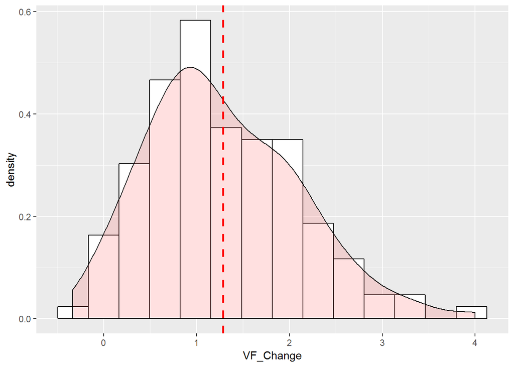

```r
Jail_clean %>%
    dplyr::filter(in.analysis.sample1 == TRUE) %>%
    ggplot2::ggplot(aes(x = VF_Change)) +
    geom_histogram(aes(y=..density..),
                   binwidth=.33,
                   colour="black",
                   fill="white") +
    geom_density(alpha=.2,
                 fill="#FF6666") +
    geom_vline(aes(xintercept=mean(VF_Change, na.rm=T)),   # Ignore NA values for mean
               color="red",
               linetype="dashed",
               size=1)
```

## Blind Love Change

```r
Jail_clean %>%
    dplyr::filter(in.analysis.sample1 == TRUE) %>%
    furniture::tableF(BL_Change)
```

```
-----------------------------------------------------------------
 BL_Change          Freq CumFreq Percent CumPerc Valid  CumValid
 -3                 1    1       0.76%   0.76%   0.77%  0.77%
 -2.33333333333333  2    3       1.53%   2.29%   1.54%  2.31%
 -2                 2    5       1.53%   3.82%   1.54%  3.85%
 -1.33333333333333  12   17      9.16%   12.98%  9.23%  13.08%
 -1                 18   35      13.74%  26.72%  13.85% 26.92%
 -0.666666666666667 17   52      12.98%  39.69%  13.08% 40.00%
 -0.333333333333333 17   69      12.98%  52.67%  13.08% 53.08%
 -0.166666666666667 1    70      0.76%   53.44%  0.77%  53.85%
 0                  29   99      22.14%  75.57%  22.31% 76.15%
 0.333333333333333  9    108     6.87%   82.44%  6.92%  83.08%
 0.333333333333334  1    109     0.76%   83.21%  0.77%  83.85%
 0.5                1    110     0.76%   83.97%  0.77%  84.62%
 0.666666666666667  6    116     4.58%   88.55%  4.62%  89.23%
 1                  6    122     4.58%   93.13%  4.62%  93.85%
 1.33333333333333   2    124     1.53%   94.66%  1.54%  95.38%
 2                  2    126     1.53%   96.18%  1.54%  96.92%
 2.33333333333333   1    127     0.76%   96.95%  0.77%  97.69%
 2.66666666666667   2    129     1.53%   98.47%  1.54%  99.23%
 4                  1    130     0.76%   99.24%  0.77%  100.00%
 Missing            1    131     0.76%   100.00%
-----------------------------------------------------------------
```

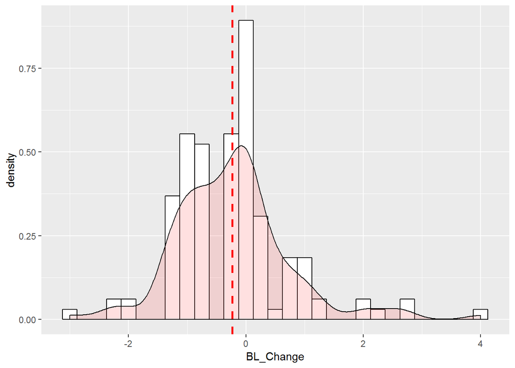

```r
Jail_clean %>%
    dplyr::filter(in.analysis.sample1 == TRUE) %>%
    ggplot2::ggplot(aes(x = BL_Change)) +
    geom_histogram(aes(y=..density..),
                   binwidth=.25,
                   colour="black",
                   fill="white") +
    geom_density(alpha=.2,
                 fill="#FF6666") +
    geom_vline(aes(xintercept=mean(BL_Change, na.rm=T)),   # Ignore NA values for mean
               color="red",
               linetype="dashed",
               size=1)
```

## Control Scale Change

```r
Jail_clean %>%
    dplyr::filter(in.analysis.sample1 == TRUE) %>%
    furniture::tableF(Control_Change)
```

```
-----------------------------------------------------------------
 Control_Change     Freq CumFreq Percent CumPerc Valid  CumValid
 -2.33333333333333  1    1       0.76%   0.76%   0.79%  0.79%
 -2                 1    2       0.76%   1.53%   0.79%  1.57%
 -1.33333333333333  1    3       0.76%   2.29%   0.79%  2.36%
 -1                 2    5       1.53%   3.82%   1.57%  3.94%
 -0.666666666666667 8    13      6.11%   9.92%   6.30%  10.24%
 -0.333333333333334 1    14      0.76%   10.69%  0.79%  11.02%
 -0.333333333333333 10   24      7.63%   18.32%  7.87%  18.90%
 0                  32   56      24.43%  42.75%  25.20% 44.09%
 0.166666666666667  1    57      0.76%   43.51%  0.79%  44.88%
 0.333333333333333  21   78      16.03%  59.54%  16.54% 61.42%
 0.333333333333334  4    82      3.05%   62.60%  3.15%  64.57%
 0.666666666666667  21   103     16.03%  78.63%  16.54% 81.10%
 1                  11   114     8.40%   87.02%  8.66%  89.76%
 1.33333333333333   9    123     6.87%   93.89%  7.09%  96.85%
 1.66666666666667   1    124     0.76%   94.66%  0.79%  97.64%
 2                  1    125     0.76%   95.42%  0.79%  98.43%
 2.33333333333333   1    126     0.76%   96.18%  0.79%  99.21%
 3.33333333333333   1    127     0.76%   96.95%  0.79%  100.00%
 Missing            4    131     3.05%   100.00%
-----------------------------------------------------------------
```

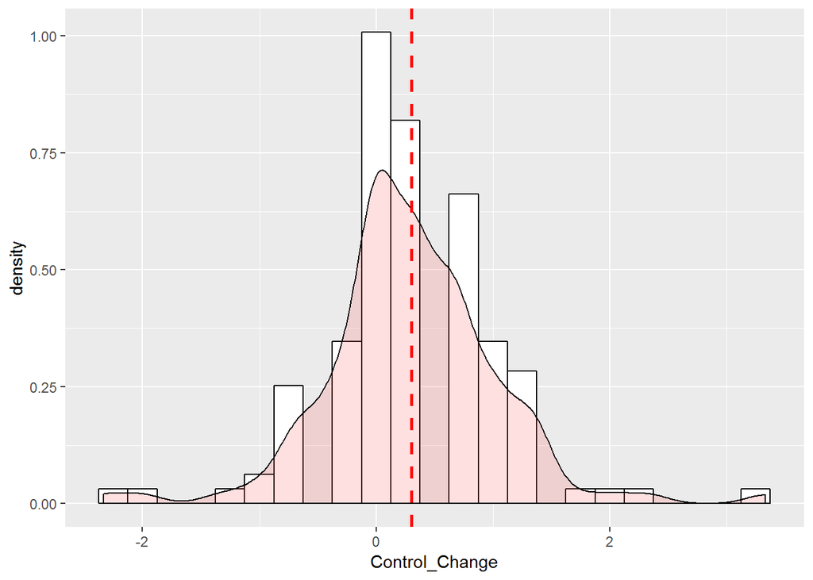

```r
Jail_clean %>%
    dplyr::filter(in.analysis.sample1 == TRUE) %>%
    ggplot2::ggplot(aes(x = Control_Change)) +
    geom_histogram(aes(y=..density..),
                   binwidth=.25,
                   colour="black",
                   fill="white") +
    geom_density(alpha=.2,
                 fill="#FF6666") +
    geom_vline(aes(xintercept=mean(Control_Change, na.rm=T)),   # Ignore NA values for mean
               color="red",
               linetype="dashed",
               size=1)
```

# Creating Long Dataset

- This is the analysis sample: Cases not used in analyses were dropped.
  - Cases without complete data on predictors were dropped because complete data on predictors is required for analysis.
  - Cases missing all outcomes were dropped. Cases with at least one outcome can be used in analyses.

```r
Jail_clean_long <- Jail_clean %>%
    dplyr::filter(in.analysis.sample1 == TRUE) %>%
    dplyr::select(ID,
                  Age,
                  #AgeDecades,
                  Age_Groups,
                  Ethnicity,
                  Ethnicity_Dich,
                  Education_collapsed,
                  Education_3cat,
                  RelationshipEducation,
                  RelEd_Dich,
                  FinancialWorry_cat,
                  Income,
                  Income10K,
                  Gender,
                  Div_Dich,
                  BL_Change,
                  VF_Change,
                  Control_Change) %>%
    tidyr::gather(key = var,
                  value = Change.Score,
                  BL_Change,
                  VF_Change,
                  Control_Change) %>%
    dplyr::mutate_at(vars(ID, var), factor) %>%
    dplyr::arrange(ID, var)
```

```r
Jail_clean_long
```

| ID | Age | Age_Groups | Ethnicity | Ethnicity_Dich | Education_collapsed | Education_3cat | RelationshipEducation | RelEd_Dich | FinancialWorry_cat | Income | Income10K | Gender | Div_Dich | var | Change.Score |
| --- | --- | --- | --- | --- | --- | --- | --- | --- | --- | --- | --- | --- | --- | --- | --- |
| 7219.1 | 21 | 18-30 | Hispanic/Latino | Else | High school graduate/GED/No degree | High school graduate/GED/No degree | Some | Some/A lot | Once in a while | 25000 | 2.50 | Male | Never Divorced | BL_Change | -0.6666667 |
| 7219.1 | 21 | 18-30 | Hispanic/Latino | Else | High school graduate/GED/No degree | High school graduate/GED/No degree | Some | Some/A lot | Once in a while | 25000 | 2.50 | Male | Never Divorced | Control_Change | 0.0000000 |
| 7219.1 | 21 | 18-30 | Hispanic/Latino | Else | High school graduate/GED/No degree | High school graduate/GED/No degree | Some | Some/A lot | Once in a while | 25000 | 2.50 | Male | Never Divorced | VF_Change | 0.3333333 |
| 7220.1 | 25 | 18-30 | Hispanic/Latino | Else | High school graduate/GED/No degree | High school graduate/GED/No degree | A lot | Some/A lot | Often, Almost all the time | NA | NA | Male | Never Divorced | BL_Change | -1.3333333 |
| 7220.1 | 25 | 18-30 | Hispanic/Latino | Else | High school graduate/GED/No degree | High school graduate/GED/No degree | A lot | Some/A lot | Often, Almost all the time | NA | NA | Male | Never Divorced | Control_Change | 1.3333333 |
| 7220.1 | 25 | 18-30 | Hispanic/Latino | Else | High school graduate/GED/No degree | High school graduate/GED/No degree | A lot | Some/A lot | Often, Almost all the time | NA | NA | Male | Never Divorced | VF_Change | 3.0000000 |
| 7222.1 | 26 | 18-30 | Caucasian | Caucasian | High school graduate/GED/No degree | High school graduate/GED/No degree | None | None | Often, Almost all the time | 25000 | 2.50 | Male | Never Divorced | BL_Change | 0.0000000 |
| 7222.1 | 26 | 18-30 | Caucasian | Caucasian | High school graduate/GED/No degree | High school graduate/GED/No degree | None | None | Often, Almost all the time | 25000 | 2.50 | Male | Never Divorced | Control_Change | 1.3333333 |
| 7222.1 | 26 | 18-30 | Caucasian | Caucasian | High school graduate/GED/No degree | High school graduate/GED/No degree | None | None | Often, Almost all the time | 25000 | 2.50 | Male | Never Divorced | VF_Change | 2.0000000 |
| 7224.1 | 29 | 18-30 | Caucasian | Caucasian | High school graduate/GED/No degree | High school graduate/GED/No degree | None | None | Often, Almost all the time | 50000 | 5.00 | Male | Divorced | BL_Change | 1.0000000 |

[output cut: 383 more lines]

# Creating Long Dataset with all available data on significant predictors

- This is the analysis sample: Cases not used in analyses were dropped.
  - Cases without complete data on significant predictors were dropped because complete data on predictors is required for analysis.
  - Cases missing all outcomes were dropped. Cases with at least one outcome can be used in analyses.

```r
Jail_clean_long2 <- Jail_clean %>%
    dplyr::filter(in.analysis.sample2 == TRUE) %>%
    dplyr::select(ID,
                  Age,
                  #AgeDecades,
                  Age_Groups,
                  Ethnicity,
                  Ethnicity_Dich,
                  Education_collapsed,
                  Education_3cat,
                  RelationshipEducation,
                  RelEd_Dich,
                  FinancialWorry_cat,
                  Income,
                  Income10K,
                  Gender,
                  Div_Dich,
                  BL_Change,
                  VF_Change,
                  Control_Change) %>%
    tidyr::gather(key = var,
                  value = Change.Score,
                  BL_Change,
                  VF_Change,
                  Control_Change) %>%
    dplyr::mutate_at(vars(ID, var), factor) %>%
    dplyr::arrange(ID, var)
```

```r
Jail_clean_long2
```

| ID | Age | Age_Groups | Ethnicity | Ethnicity_Dich | Education_collapsed | Education_3cat | RelationshipEducation | RelEd_Dich | FinancialWorry_cat | Income | Income10K | Gender | Div_Dich | var | Change.Score |
| --- | --- | --- | --- | --- | --- | --- | --- | --- | --- | --- | --- | --- | --- | --- | --- |
| 7219.1 | 21 | 18-30 | Hispanic/Latino | Else | High school graduate/GED/No degree | High school graduate/GED/No degree | Some | Some/A lot | Once in a while | 25000 | 2.50 | Male | Never Divorced | BL_Change | -0.6666667 |
| 7219.1 | 21 | 18-30 | Hispanic/Latino | Else | High school graduate/GED/No degree | High school graduate/GED/No degree | Some | Some/A lot | Once in a while | 25000 | 2.50 | Male | Never Divorced | Control_Change | 0.0000000 |
| 7219.1 | 21 | 18-30 | Hispanic/Latino | Else | High school graduate/GED/No degree | High school graduate/GED/No degree | Some | Some/A lot | Once in a while | 25000 | 2.50 | Male | Never Divorced | VF_Change | 0.3333333 |
| 7220.1 | 25 | 18-30 | Hispanic/Latino | Else | High school graduate/GED/No degree | High school graduate/GED/No degree | A lot | Some/A lot | Often, Almost all the time | NA | NA | Male | Never Divorced | BL_Change | -1.3333333 |
| 7220.1 | 25 | 18-30 | Hispanic/Latino | Else | High school graduate/GED/No degree | High school graduate/GED/No degree | A lot | Some/A lot | Often, Almost all the time | NA | NA | Male | Never Divorced | Control_Change | 1.3333333 |
| 7220.1 | 25 | 18-30 | Hispanic/Latino | Else | High school graduate/GED/No degree | High school graduate/GED/No degree | A lot | Some/A lot | Often, Almost all the time | NA | NA | Male | Never Divorced | VF_Change | 3.0000000 |
| 7222.1 | 26 | 18-30 | Caucasian | Caucasian | High school graduate/GED/No degree | High school graduate/GED/No degree | None | None | Often, Almost all the time | 25000 | 2.50 | Male | Never Divorced | BL_Change | 0.0000000 |
| 7222.1 | 26 | 18-30 | Caucasian | Caucasian | High school graduate/GED/No degree | High school graduate/GED/No degree | None | None | Often, Almost all the time | 25000 | 2.50 | Male | Never Divorced | Control_Change | 1.3333333 |
| 7222.1 | 26 | 18-30 | Caucasian | Caucasian | High school graduate/GED/No degree | High school graduate/GED/No degree | None | None | Often, Almost all the time | 25000 | 2.50 | Male | Never Divorced | VF_Change | 2.0000000 |
| 7224.1 | 29 | 18-30 | Caucasian | Caucasian | High school graduate/GED/No degree | High school graduate/GED/No degree | None | None | Often, Almost all the time | 50000 | 5.00 | Male | Divorced | BL_Change | 1.0000000 |

[output cut: 383 more lines]

# Creating Long long Dataset for MLM over TIme

- This is the analysis sample: Cases not used in analyses were dropped.
  - Cases without complete data on predictors were dropped because complete data on predictors is required for analysis.
  - Cases missing all outcomes were dropped. Cases with at least one outcome can be used in analyses.

```r
Jail_clean_longlong <- Jail_clean %>%
    dplyr::filter(in.analysis.sample3 == TRUE) %>%
    # dplyr::rename(Healthy_Rel_SkillsPost = Healthy_Rel_Skills,
    #               Partner_SelectionPost = Partner_Selection,
    #               Past_Rel_BehavPost = Past_Rel_Behav,
    #               Rel_Behav_AttitPost = Rel_Behav_Attit,
    #               Healthy_Rel_SkillsRPre = Healthy_Rel_Skills_Before,
    #               Partner_SelectionRPre = Partner_Selection_Before,
    #               Past_Rel_BehavRPre = Past_Rel_Behav_Before,
    #               Rel_Behav_AttitRPre = Rel_Behav_Attit_Before) %>%
    dplyr::select(ID,
                  Age,
                  #AgeDecades,
                  Age_Groups,
                  Ethnicity,
                  Ethnicity_Dich,
                  Education_collapsed,
                  Education_3cat,
                  RelationshipEducation,
                  RelEd_Dich,
                  FinancialWorry_cat,
                  Income,
                  Income10K,
                  Gender,
                  Div_Dich,
                  BL_T1,
                  VF_T1,
                  Control_T1,
                  BL_T2,
                  VF_After,
                  Control_T2) %>%
    tidyr::gather(key = var,
                  value = Score,
                  BL_T1,
                  VF_T1,
                  Control_T1,
                  BL_T2,
                  VF_After,
                  Control_T2) %>%
     tidyr::separate(col = var, into = c("Domain","Time"), sep = -4) %>%
    dplyr::mutate_at(vars(ID,Domain, Time), factor) %>%
    dplyr::arrange(ID, Domain, Time) %>%
    dplyr::mutate(Time = factor(Time,
                                levels = c("Pre", "Post")))
```

```r
Jail_clean_longlong
```

| ID | Age | Age_Groups | Ethnicity | Ethnicity_Dich | Education_collapsed | Education_3cat | RelationshipEducation | RelEd_Dich | FinancialWorry_cat | Income | Income10K | Gender | Div_Dich | Domain | Time | Score |
| --- | --- | --- | --- | --- | --- | --- | --- | --- | --- | --- | --- | --- | --- | --- | --- | --- |
| 7219.1 | 21 | 18-30 | Hispanic/Latino | Else | High school graduate/GED/No degree | High school graduate/GED/No degree | Some | Some/A lot | Once in a while | 25000 | 2.50 | Male | Never Divorced | B | NA | 4.333333 |
| 7219.1 | 21 | 18-30 | Hispanic/Latino | Else | High school graduate/GED/No degree | High school graduate/GED/No degree | Some | Some/A lot | Once in a while | 25000 | 2.50 | Male | Never Divorced | B | NA | 3.666667 |
| 7219.1 | 21 | 18-30 | Hispanic/Latino | Else | High school graduate/GED/No degree | High school graduate/GED/No degree | Some | Some/A lot | Once in a while | 25000 | 2.50 | Male | Never Divorced | Contro | NA | 3.666667 |
| 7219.1 | 21 | 18-30 | Hispanic/Latino | Else | High school graduate/GED/No degree | High school graduate/GED/No degree | Some | Some/A lot | Once in a while | 25000 | 2.50 | Male | Never Divorced | Contro | NA | 3.666667 |
| 7219.1 | 21 | 18-30 | Hispanic/Latino | Else | High school graduate/GED/No degree | High school graduate/GED/No degree | Some | Some/A lot | Once in a while | 25000 | 2.50 | Male | Never Divorced | V | NA | 4.000000 |
| 7219.1 | 21 | 18-30 | Hispanic/Latino | Else | High school graduate/GED/No degree | High school graduate/GED/No degree | Some | Some/A lot | Once in a while | 25000 | 2.50 | Male | Never Divorced | VF_A | NA | 4.333333 |
| 7220.1 | 25 | 18-30 | Hispanic/Latino | Else | High school graduate/GED/No degree | High school graduate/GED/No degree | A lot | Some/A lot | Often, Almost all the time | NA | NA | Male | Never Divorced | B | NA | 4.666667 |
| 7220.1 | 25 | 18-30 | Hispanic/Latino | Else | High school graduate/GED/No degree | High school graduate/GED/No degree | A lot | Some/A lot | Often, Almost all the time | NA | NA | Male | Never Divorced | B | NA | 3.333333 |
| 7220.1 | 25 | 18-30 | Hispanic/Latino | Else | High school graduate/GED/No degree | High school graduate/GED/No degree | A lot | Some/A lot | Often, Almost all the time | NA | NA | Male | Never Divorced | Contro | NA | 3.666667 |
| 7220.1 | 25 | 18-30 | Hispanic/Latino | Else | High school graduate/GED/No degree | High school graduate/GED/No degree | A lot | Some/A lot | Often, Almost all the time | NA | NA | Male | Never Divorced | Contro | NA | 5.000000 |

[output cut: 848 more lines]

# Using Collapsed Reasonse Options: Creating Long long Dataset 2 for MLM over TIme

- This is the analysis sample: Cases not used in analyses were dropped.
  - Cases without complete data on predictors were dropped because complete data on predictors is required for analysis.
  - Cases missing all outcomes were dropped. Cases with at least one outcome can be used in analyses.

```r
Jail_clean_longlong2 <- Jail_clean %>%
    dplyr::filter(in.analysis.sample3 == TRUE) %>%
    # dplyr::rename(Healthy_Rel_SkillsPost = Healthy_Rel_Skills.3,
    #               Partner_SelectionPost = Partner_Selection.3,
    #               Past_Rel_BehavPost = Past_Rel_Behav.3,
    #               Rel_Behav_AttitPost = Rel_Behav_Attit.3,
    #               Healthy_Rel_SkillsRPre = Healthy_Rel_Skills_Before.3,
    #               Partner_SelectionRPre = Partner_Selection_Before.3,
    #               Past_Rel_BehavRPre = Past_Rel_Behav_Before.3,
    #               Rel_Behav_AttitRPre = Rel_Behav_Attit_Before.3) %>%
    dplyr::select(ID,
                  Age,
                  #AgeDecades,
                  Age_Groups,
                  Ethnicity,
                  Ethnicity_Dich,
                  Education_collapsed,
                  Education_3cat,
                  RelationshipEducation,
                  RelEd_Dich,
                  FinancialWorry_cat,
                  Income,
                  Income10K,
                  Gender,
                  Div_Dich,
                  BL_T1,
                  VF_T1,
                  Control_T1,
                  BL_T2,
                  VF_After,
                  Control_T2) %>%
    tidyr::gather(key = var,
                  value = Score,
                  BL_T1,
                  VF_T1,
                  Control_T1,
                  BL_T2,
                  VF_After,
                  Control_T2) %>%
    tidyr::separate(col = var, into = c("Domain","Time"), sep = -4) %>%
    dplyr::mutate_at(vars(ID,Domain, Time), factor) %>%
    dplyr::arrange(ID, Domain, Time) %>%
    dplyr::mutate(Time = factor(Time,
                                levels = c("Pre", "Post")))
```

# Using Collapsed Reasonse Options: Creating Long long Dataset 2 for MLM over TIme

- This is the analysis sample: Cases not used in analyses were dropped.
  - Cases without complete data on predictors were dropped because complete data on predictors is required for analysis.
  - Cases missing all outcomes were dropped. Cases with at least one outcome can be used in analyses.

```r
Jail_clean_longlong4 <- Jail_clean %>%
    dplyr::filter(in.analysis.sample3 == TRUE) %>%
    # dplyr::rename(Healthy_Rel_SkillsPost = Healthy_Rel_Skills.3,
    #               Partner_SelectionPost = Partner_Selection.3,
    #               Past_Rel_BehavPost = Past_Rel_Behav.3,
    #               Rel_Behav_AttitPost = Rel_Behav_Attit.3,
    #               Healthy_Rel_SkillsRPre = Healthy_Rel_Skills_Before.3,
    #               Partner_SelectionRPre = Partner_Selection_Before.3,
    #               Past_Rel_BehavRPre = Past_Rel_Behav_Before.3,
    #               Rel_Behav_AttitRPre = Rel_Behav_Attit_Before.3) %>%
    dplyr::select(ID,
                  Age,
                  #AgeDecades,
                  Age_Groups,
                  Ethnicity,
                  Ethnicity_Dich,
                  Education_collapsed,
                  Education_3cat,
                  RelationshipEducation,
                  RelEd_Dich,
                  FinancialWorry_cat,
                  Income,
                  Income10K,
                  Gender,
                  Div_Dich,
                  BL_T1,
                  VF_T1,
                  Control_T1,
                  BL_T2,
                  VF_After,
                  Control_T2) %>%
    tidyr::gather(key = var,
                  value = Score,
                  BL_T1,
                  VF_T1,
                  Control_T1,
                  BL_T2,
                  VF_After,
                  Control_T2) %>%
    tidyr::separate(col = var, into = c("Domain","Time"), sep = -4) %>%
    dplyr::mutate_at(vars(ID,Domain, Time), factor) %>%
    dplyr::arrange(ID, Domain, Time) %>%
    dplyr::mutate(Time = factor(Time,
                                levels = c("Pre", "Post")))
```

# Saving data Set

```r
save(Jail_clean, file="./Data/Jail_clean.Rda")
save(Jail_clean_long, file="./Data/Jail_clean_long.Rda")
save(Jail_clean_long2, file="./Data/Jail_clean_long2.Rda")
save(Jail_clean_longlong, file="./Data/Jail_clean_longlong.Rda")
save(Jail_clean_longlong2, file="./Data/Jail_clean_longlong2.Rda")
save(Jail_clean_longlong4, file="./Data/Jail_clean_longlong4.Rda")
```